# Codebook Study 1

### Metadata

#### Description

**Dataset name**: The Effects of Making Public Service Employees Aware of Their Prosocial and Societal Impact: A Micro-Intervention

Dataset for Study 1 of Vogel, D., & Willems, J. The Effects of Making Public Service Employees Aware of Their Prosocial and Societal Impact: A Micro-Intervention. Journal of Public Administration Research and Theory.

**Metadata for search engines**

- **Temporal Coverage**: December 2017
- **Spatial Coverage**: U.S.
- **Citation**:
- **URL**:
- **Identifier**:
- **Date published**: 2019-12-01
- **Creator**:Dominik Vogel, Jurgen Willems
  - **keywords**: *id*, *startdate*, *submitdate*, *lastpage*, *treatment*, *willingnessjobrec1*, *willingnessjobrec2*, *paffect1*, *paffect2*, *paffect3*, *paffect4*, *paffect5*, *paffect6*, *naffect1*, *naffect2*, *naffect3*, *naffect4*, *naffect5*, *naffect6*, *turnover1*, *turnover2*, *turnover3*, *prosocialimpact1*, *prosocialimpact2*, *prosocialimpact3*, *manipulationcheck*, *taskvariety1*, *taskvariety2*, *taskvariety3*, *taskvariety4*, *taskvariety5*, *taskanalyz1*, *taskanalyz2*, *taskanalyz3*, *taskanalyz4*, *attention1*, *autonomy1*, *autonomy2*, *autonomy3*, *beneficiaries1*, *beneficiaries2*, *attention2*, *manager*, *gender*, *yearbirth*, *educator*, *sector*, *subsector*, *atwork*, *duration_treatment_general*, *duration_treatment_prosocial* and *duration_treatment_societal*

## Variables

### id

ID

#### Distribution

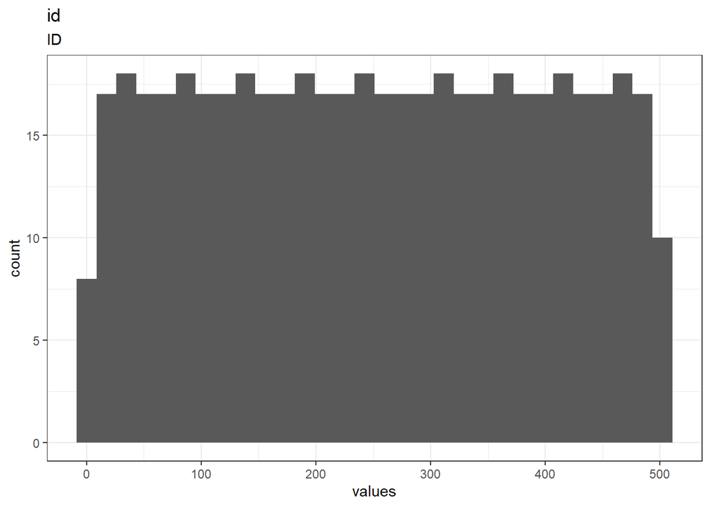

0 missing values.

#### Summary statistics

| name | label | data_type | missing | complete | n | mean | sd | p0 | p25 | p50 | p75 | p100 | hist |
| --- | --- | --- | --- | --- | --- | --- | --- | --- | --- | --- | --- | --- | --- |
| id | ID | numeric | 0 | 503 | 503 | 252 | 145.35 | 1 | 126.5 | 252 | 377.5 | 503 | ▇▇▇▇▇▇▇▇ |

### startdate

Start Date

#### Distribution

```
## 503  unique, categorical values, so not shown.
```

0 missing values.

#### Summary statistics

| name | label | data_type | missing | complete | n | n_unique | median | min | max |
| --- | --- | --- | --- | --- | --- | --- | --- | --- | --- |
| startdate | Start Date | POSIXct | 0 | 503 | 503 | 503 | 2017-12-12 | 2017-12-11 | 2017-12-19 |

### submitdate

End Date

#### Distribution

```
## 450  unique, categorical values, so not shown.
```

53 missing values.

#### Summary statistics

| name | label | data_type | missing | complete | n | n_unique | median | min | max |
| --- | --- | --- | --- | --- | --- | --- | --- | --- | --- |
| submitdate | End Date | POSIXct | 53 | 450 | 503 | 450 | 2017-12-12 | 2017-12-11 | 2017-12-19 |

### lastpage

Last page of questionnaire finished

#### Distribution

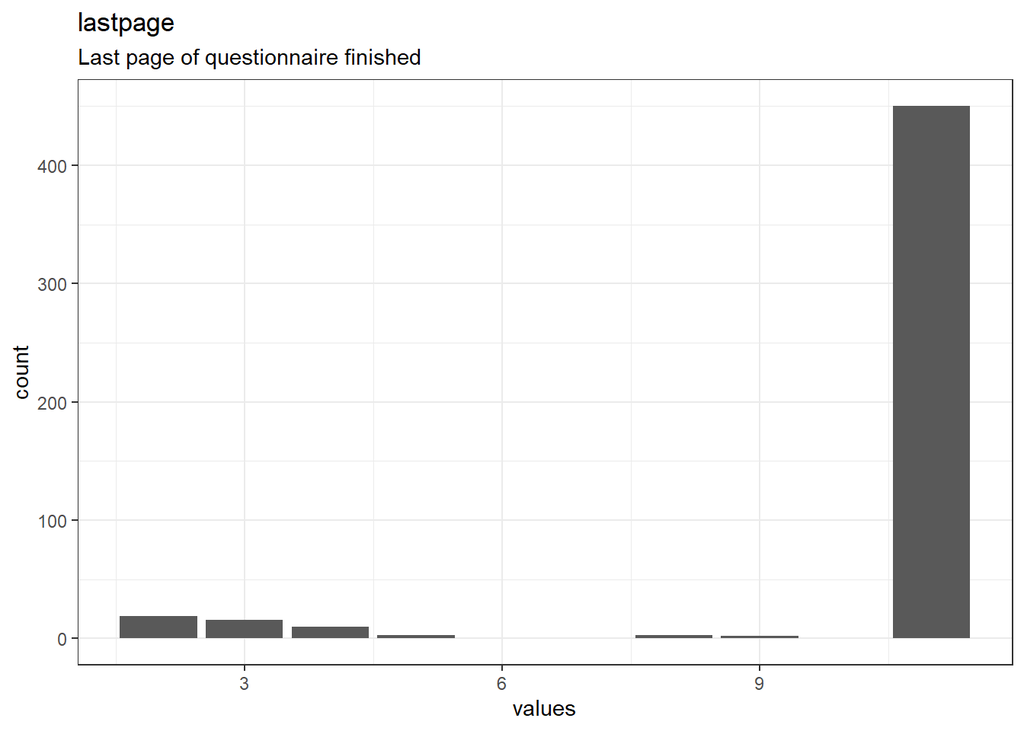

0 missing values.

#### Summary statistics

| name | label | data_type | missing | complete | n | mean | sd | p0 | p25 | p50 | p75 | p100 | hist |
| --- | --- | --- | --- | --- | --- | --- | --- | --- | --- | --- | --- | --- | --- |
| lastpage | Last page of questionnaire finished | numeric | 0 | 503 | 503 | 10.2 | 2.39 | 2 | 11 | 11 | 11 | 11 | ▁▁▁▁▁▁▁▇ |

### treatment

Treatment group

#### Distribution

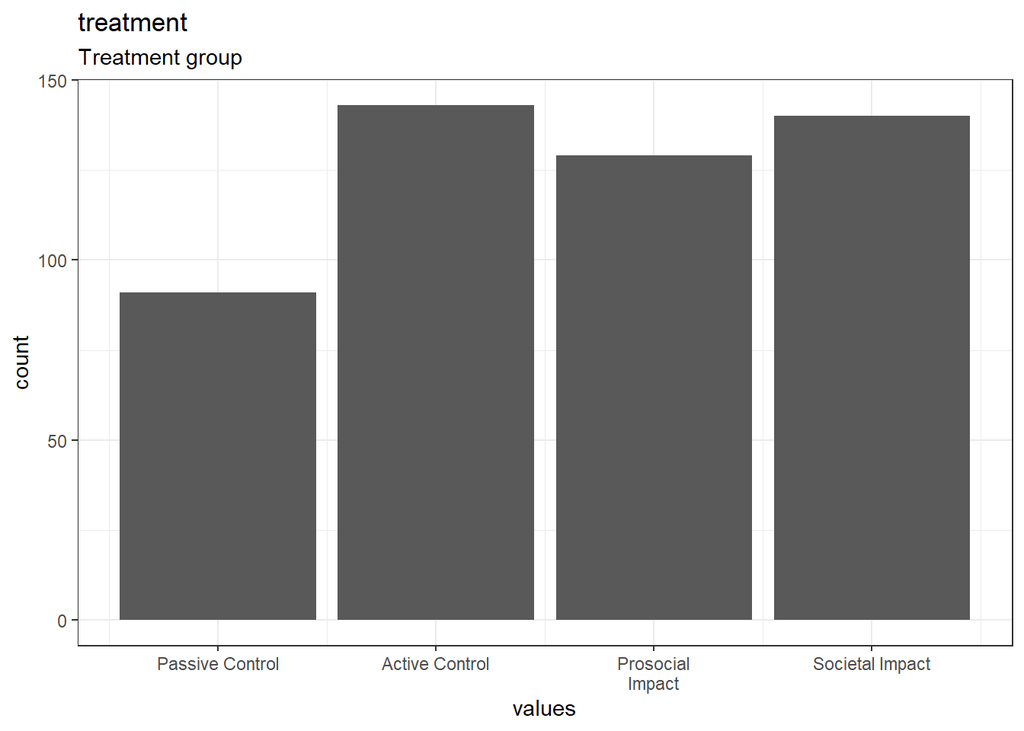

0 missing values.

#### Summary statistics

| name | label | data_type | value_labels | missing | complete | n | mean | sd | p0 | p25 | p50 | p75 | p100 | hist |
| --- | --- | --- | --- | --- | --- | --- | --- | --- | --- | --- | --- | --- | --- | --- |
| treatment | Treatment group | numeric | 1. Passive Control, 2. Active Control, 3. Prosocial Impact, 4. Societal Impact | 0 | 503 | 503 | 2.63 | 1.07 | 1 | 2 | 3 | 4 | 4 | ▅▁▇▁▁▇▁▇ |

#### Value labels

- **Passive Control**: *1*
- **Active Control**: *2*
- **Prosocial Impact**: *3*
- **Societal Impact**: *4*

### willingnessjobrec1

How likely would you recommend your job to your friends?

#### Distribution

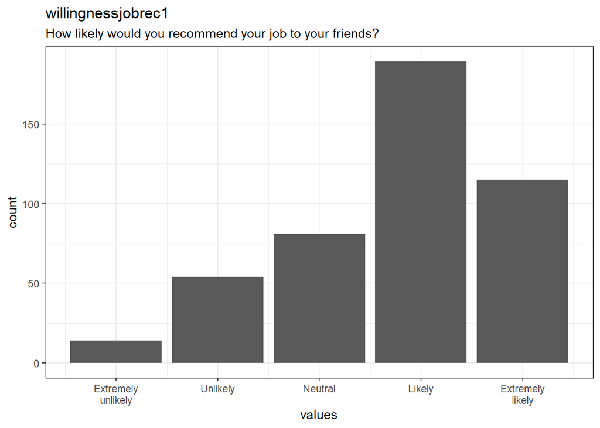

50 missing values.

#### Summary statistics

| name | label | data_type | value_labels | missing | complete | n | mean | sd | p0 | p25 | p50 | p75 | p100 | hist |
| --- | --- | --- | --- | --- | --- | --- | --- | --- | --- | --- | --- | --- | --- | --- |
| willingnessjobrec1 | How likely would you recommend your job to your friends? | numeric | 1. Extremely unlikely, 2. Unlikely, 3. Neutral, 4. Likely, 5. Extremely likely | 50 | 453 | 503 | 3.74 | 1.06 | 1 | 3 | 4 | 5 | 5 | ▁▂▁▃▁▇▁▅ |

#### Value labels

- **Extremely unlikely**: *1*
- **Unlikely**: *2*
- **Neutral**: *3*
- **Likely**: *4*
- **Extremely likely**: *5*

### willingnessjobrec2

How likely would you tell your friends NOT to do the same job you do?

#### Distribution

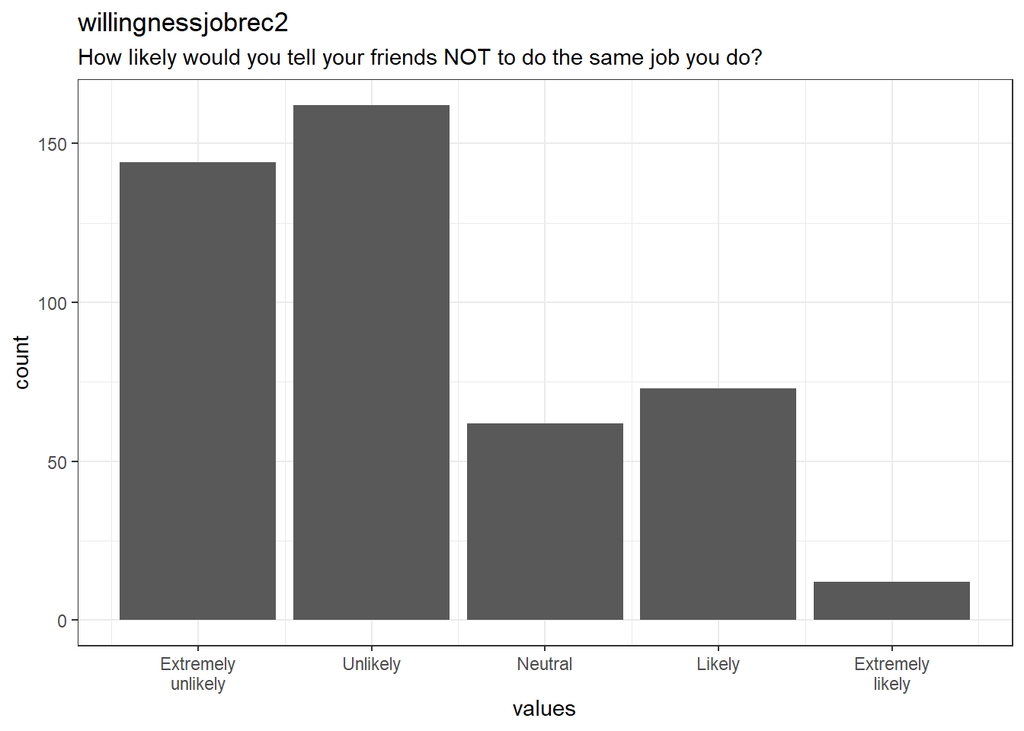

50 missing values.

#### Summary statistics

| name | label | data_type | value_labels | missing | complete | n | mean | sd | p0 | p25 | p50 | p75 | p100 | hist |
| --- | --- | --- | --- | --- | --- | --- | --- | --- | --- | --- | --- | --- | --- | --- |
| willingnessjobrec2 | How likely would you tell your friends NOT to do the same job you do? | numeric | 1. Extremely unlikely, 2. Unlikely, 3. Neutral, 4. Likely, 5. Extremely likely | 50 | 453 | 503 | 2.22 | 1.14 | 1 | 1 | 2 | 3 | 5 | ▇▇▁▃▁▃▁▁ |

#### Value labels

- **Extremely unlikely**: *1*
- **Unlikely**: *2*
- **Neutral**: *3*
- **Likely**: *4*
- **Extremely likely**: *5*

### paffect1

Positive

#### Distribution

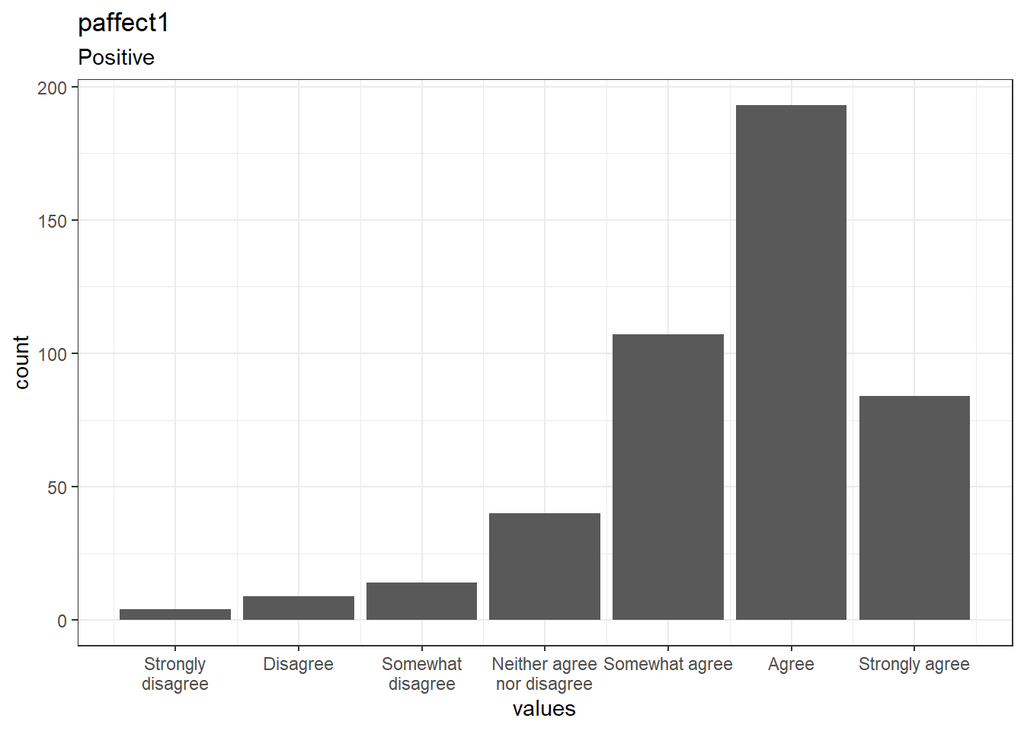

52 missing values.

#### Summary statistics

| name | label | data_type | value_labels | missing | complete | n | mean | sd | p0 | p25 | p50 | p75 | p100 | hist |
| --- | --- | --- | --- | --- | --- | --- | --- | --- | --- | --- | --- | --- | --- | --- |
| paffect1 | Positive | numeric | 1. Strongly disagree, 2. Disagree, 3. Somewhat disagree, 4. Neither agree nor disagree, 5. Somewhat agree, 6. Agree, 7. Strongly agree | 52 | 451 | 503 | 5.55 | 1.18 | 1 | 5 | 6 | 6 | 7 | ▁▁▁▂▁▅▇▃ |

#### Value labels

- **Strongly disagree**: *1*
- **Disagree**: *2*
- **Somewhat disagree**: *3*
- **Neither agree nor disagree**: *4*
- **Somewhat agree**: *5*
- **Agree**: *6*
- **Strongly agree**: *7*

### paffect2

Good

#### Distribution

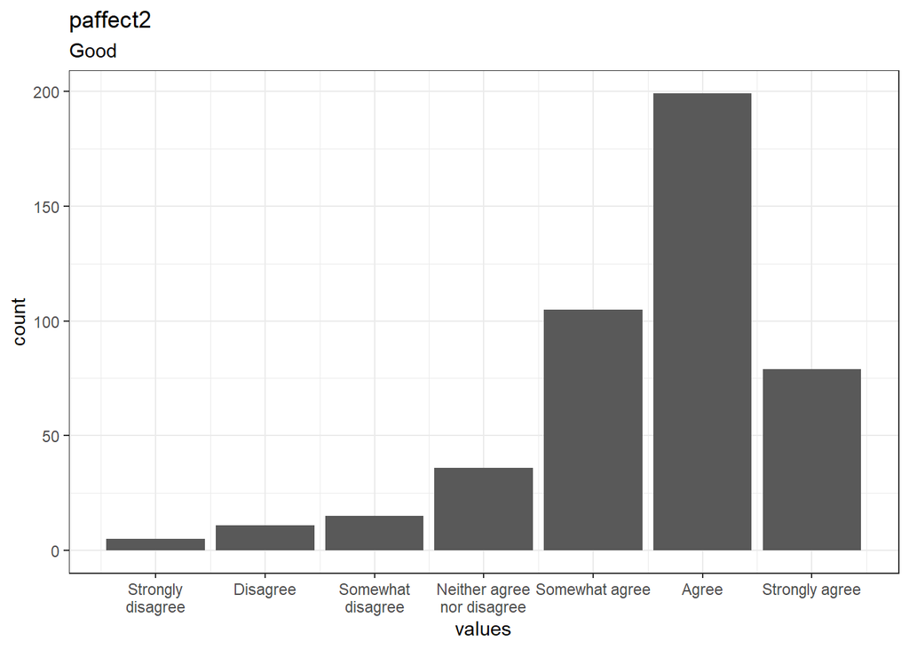

53 missing values.

#### Summary statistics

| name | label | data_type | value_labels | missing | complete | n | mean | sd | p0 | p25 | p50 | p75 | p100 | hist |
| --- | --- | --- | --- | --- | --- | --- | --- | --- | --- | --- | --- | --- | --- | --- |
| paffect2 | Good | numeric | 1. Strongly disagree, 2. Disagree, 3. Somewhat disagree, 4. Neither agree nor disagree, 5. Somewhat agree, 6. Agree, 7. Strongly agree | 53 | 450 | 503 | 5.53 | 1.22 | 1 | 5 | 6 | 6 | 7 | ▁▁▁▂▁▅▇▃ |

#### Value labels

- **Strongly disagree**: *1*
- **Disagree**: *2*
- **Somewhat disagree**: *3*
- **Neither agree nor disagree**: *4*
- **Somewhat agree**: *5*
- **Agree**: *6*
- **Strongly agree**: *7*

### paffect3

Pleasant

#### Distribution

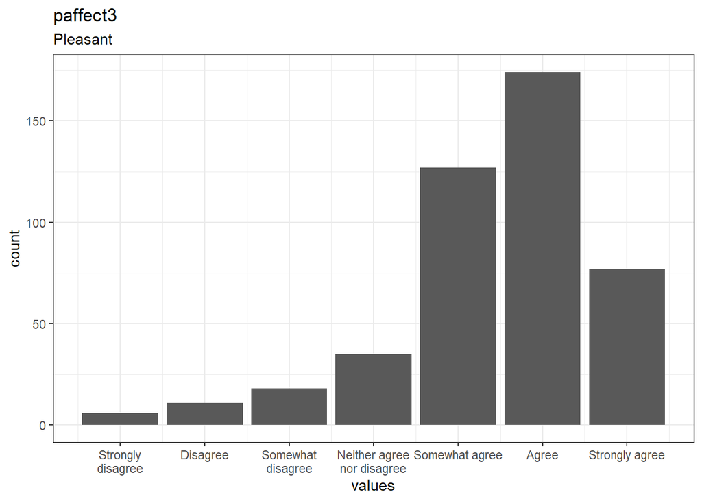

55 missing values.

#### Summary statistics

| name | label | data_type | value_labels | missing | complete | n | mean | sd | p0 | p25 | p50 | p75 | p100 | hist |
| --- | --- | --- | --- | --- | --- | --- | --- | --- | --- | --- | --- | --- | --- | --- |
| paffect3 | Pleasant | numeric | 1. Strongly disagree, 2. Disagree, 3. Somewhat disagree, 4. Neither agree nor disagree, 5. Somewhat agree, 6. Agree, 7. Strongly agree | 55 | 448 | 503 | 5.45 | 1.25 | 1 | 5 | 6 | 6 | 7 | ▁▁▁▂▁▆▇▃ |

#### Value labels

- **Strongly disagree**: *1*
- **Disagree**: *2*
- **Somewhat disagree**: *3*
- **Neither agree nor disagree**: *4*
- **Somewhat agree**: *5*
- **Agree**: *6*
- **Strongly agree**: *7*

### paffect4

Happy

#### Distribution

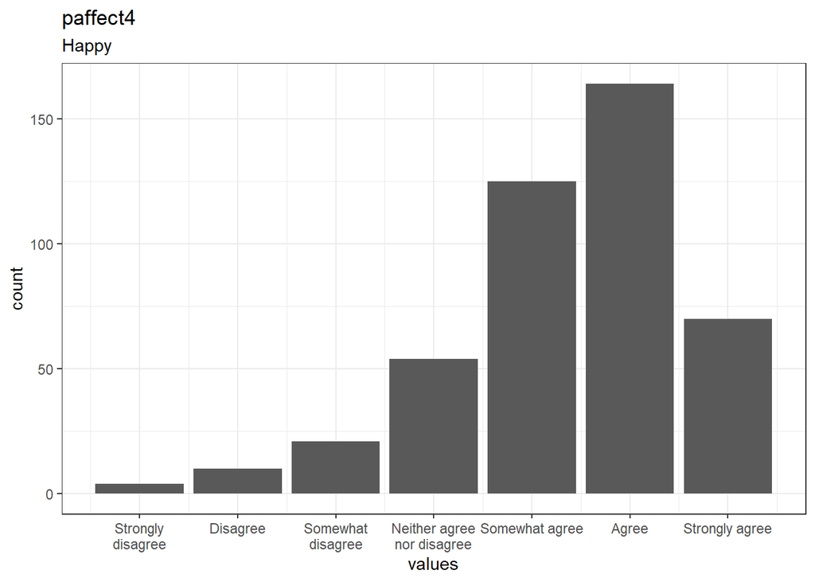

55 missing values.

#### Summary statistics

| name | label | data_type | value_labels | missing | complete | n | mean | sd | p0 | p25 | p50 | p75 | p100 | hist |
| --- | --- | --- | --- | --- | --- | --- | --- | --- | --- | --- | --- | --- | --- | --- |
| paffect4 | Happy | numeric | 1. Strongly disagree, 2. Disagree, 3. Somewhat disagree, 4. Neither agree nor disagree, 5. Somewhat agree, 6. Agree, 7. Strongly agree | 55 | 448 | 503 | 5.36 | 1.23 | 1 | 5 | 6 | 6 | 7 | ▁▁▁▂▁▆▇▃ |

#### Value labels

- **Strongly disagree**: *1*
- **Disagree**: *2*
- **Somewhat disagree**: *3*
- **Neither agree nor disagree**: *4*
- **Somewhat agree**: *5*
- **Agree**: *6*
- **Strongly agree**: *7*

### paffect5

Joyful

#### Distribution

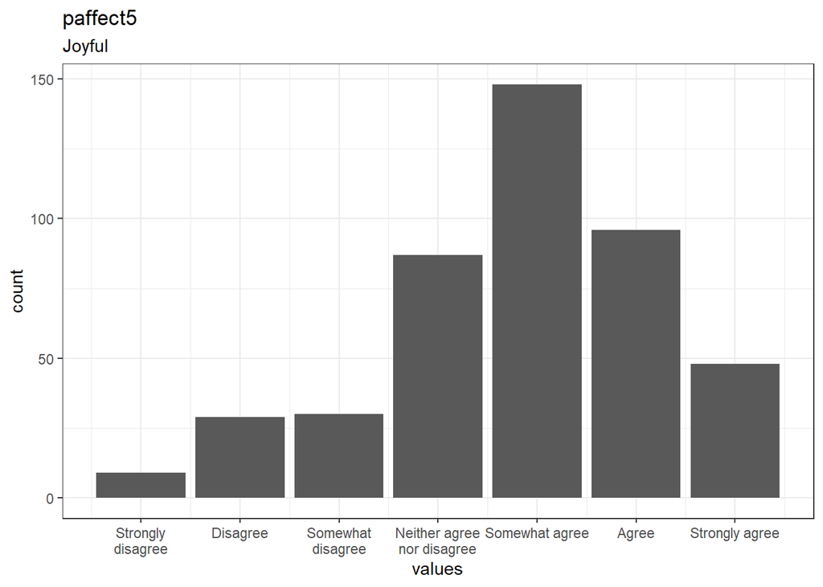

56 missing values.

#### Summary statistics

| name | label | data_type | value_labels | missing | complete | n | mean | sd | p0 | p25 | p50 | p75 | p100 | hist |
| --- | --- | --- | --- | --- | --- | --- | --- | --- | --- | --- | --- | --- | --- | --- |
| paffect5 | Joyful | numeric | 1. Strongly disagree, 2. Disagree, 3. Somewhat disagree, 4. Neither agree nor disagree, 5. Somewhat agree, 6. Agree, 7. Strongly agree | 56 | 447 | 503 | 4.83 | 1.41 | 1 | 4 | 5 | 6 | 7 | ▁▂▂▅▁▇▅▂ |

#### Value labels

- **Strongly disagree**: *1*
- **Disagree**: *2*
- **Somewhat disagree**: *3*
- **Neither agree nor disagree**: *4*
- **Somewhat agree**: *5*
- **Agree**: *6*
- **Strongly agree**: *7*

### paffect6

Contented

#### Distribution

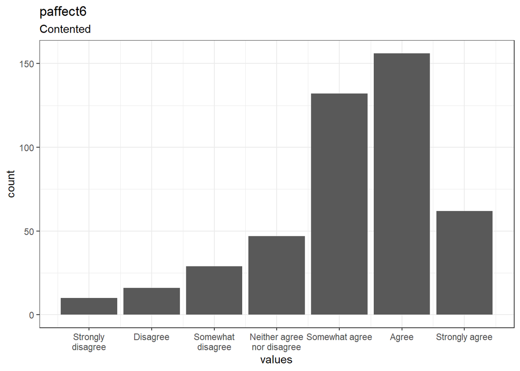

51 missing values.

#### Summary statistics

| name | label | data_type | value_labels | missing | complete | n | mean | sd | p0 | p25 | p50 | p75 | p100 | hist |
| --- | --- | --- | --- | --- | --- | --- | --- | --- | --- | --- | --- | --- | --- | --- |
| paffect6 | Contented | numeric | 1. Strongly disagree, 2. Disagree, 3. Somewhat disagree, 4. Neither agree nor disagree, 5. Somewhat agree, 6. Agree, 7. Strongly agree | 51 | 452 | 503 | 5.19 | 1.38 | 1 | 5 | 5 | 6 | 7 | ▁▁▂▂▁▇▇▃ |

#### Value labels

- **Strongly disagree**: *1*
- **Disagree**: *2*
- **Somewhat disagree**: *3*
- **Neither agree nor disagree**: *4*
- **Somewhat agree**: *5*
- **Agree**: *6*
- **Strongly agree**: *7*

### naffect1

Negative

#### Distribution

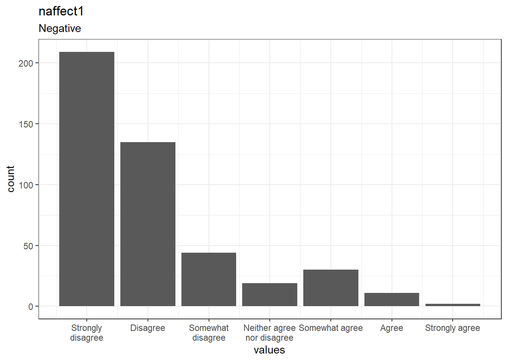

53 missing values.

#### Summary statistics

| name | label | data_type | value_labels | missing | complete | n | mean | sd | p0 | p25 | p50 | p75 | p100 | hist |
| --- | --- | --- | --- | --- | --- | --- | --- | --- | --- | --- | --- | --- | --- | --- |
| naffect1 | Negative | numeric | 1. Strongly disagree, 2. Disagree, 3. Somewhat disagree, 4. Neither agree nor disagree, 5. Somewhat agree, 6. Agree, 7. Strongly agree | 53 | 450 | 503 | 2.04 | 1.35 | 1 | 1 | 2 | 2 | 7 | ▇▅▂▁▁▁▁▁ |

#### Value labels

- **Strongly disagree**: *1*
- **Disagree**: *2*
- **Somewhat disagree**: *3*
- **Neither agree nor disagree**: *4*
- **Somewhat agree**: *5*
- **Agree**: *6*
- **Strongly agree**: *7*

### naffect2

Bad

#### Distribution

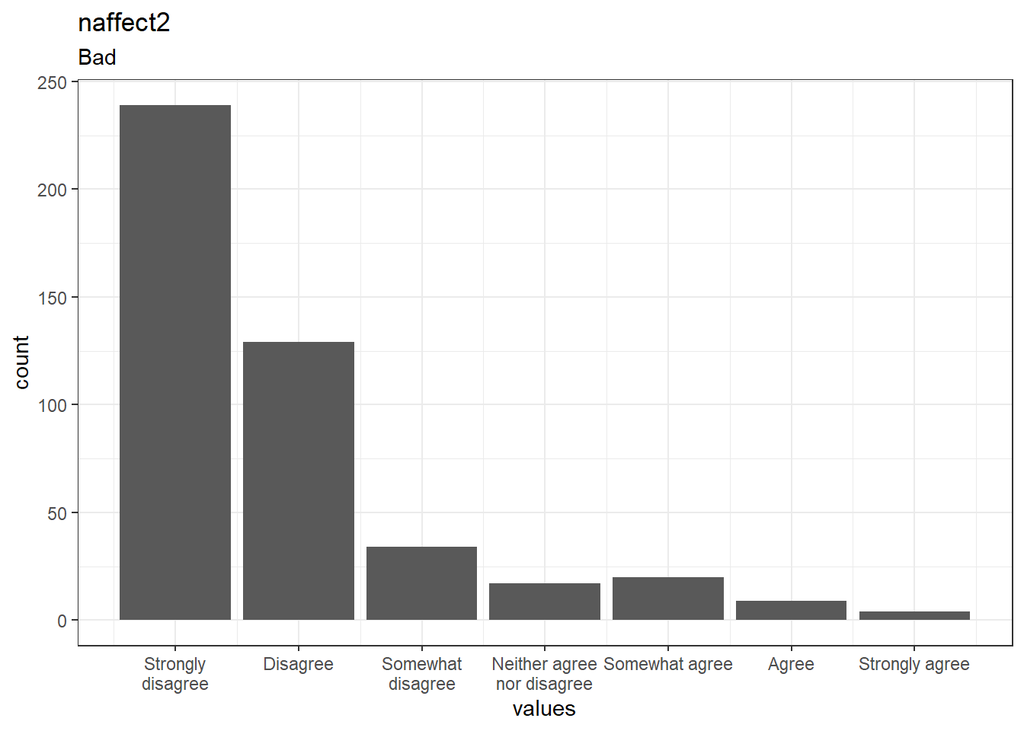

51 missing values.

#### Summary statistics

| name | label | data_type | value_labels | missing | complete | n | mean | sd | p0 | p25 | p50 | p75 | p100 | hist |
| --- | --- | --- | --- | --- | --- | --- | --- | --- | --- | --- | --- | --- | --- | --- |
| naffect2 | Bad | numeric | 1. Strongly disagree, 2. Disagree, 3. Somewhat disagree, 4. Neither agree nor disagree, 5. Somewhat agree, 6. Agree, 7. Strongly agree | 51 | 452 | 503 | 1.88 | 1.3 | 1 | 1 | 1 | 2 | 7 | ▇▅▁▁▁▁▁▁ |

#### Value labels

- **Strongly disagree**: *1*
- **Disagree**: *2*
- **Somewhat disagree**: *3*
- **Neither agree nor disagree**: *4*
- **Somewhat agree**: *5*
- **Agree**: *6*
- **Strongly agree**: *7*

### naffect3

Unpleasant

#### Distribution

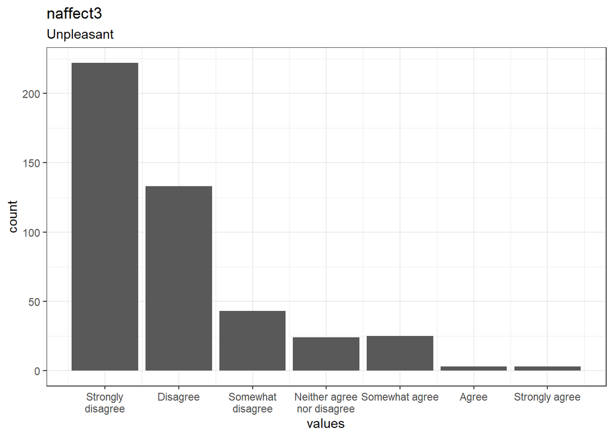

50 missing values.

#### Summary statistics

| name | label | data_type | value_labels | missing | complete | n | mean | sd | p0 | p25 | p50 | p75 | p100 | hist |
| --- | --- | --- | --- | --- | --- | --- | --- | --- | --- | --- | --- | --- | --- | --- |
| naffect3 | Unpleasant | numeric | 1. Strongly disagree, 2. Disagree, 3. Somewhat disagree, 4. Neither agree nor disagree, 5. Somewhat agree, 6. Agree, 7. Strongly agree | 50 | 453 | 503 | 1.94 | 1.25 | 1 | 1 | 2 | 2 | 7 | ▇▅▂▁▁▁▁▁ |

#### Value labels

- **Strongly disagree**: *1*
- **Disagree**: *2*
- **Somewhat disagree**: *3*
- **Neither agree nor disagree**: *4*
- **Somewhat agree**: *5*
- **Agree**: *6*
- **Strongly agree**: *7*

### naffect4

Sad

#### Distribution

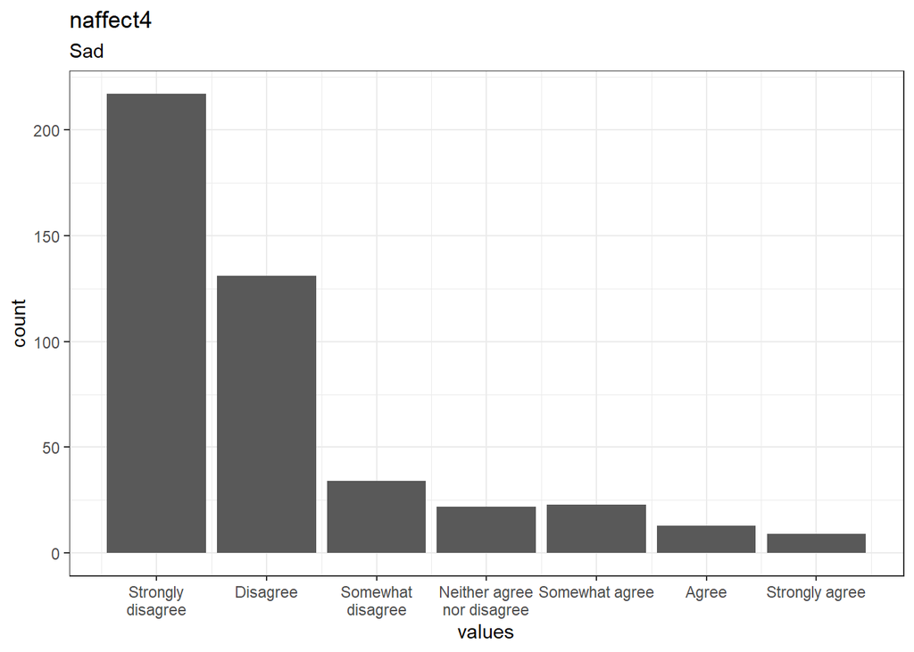

54 missing values.

#### Summary statistics

| name | label | data_type | value_labels | missing | complete | n | mean | sd | p0 | p25 | p50 | p75 | p100 | hist |
| --- | --- | --- | --- | --- | --- | --- | --- | --- | --- | --- | --- | --- | --- | --- |
| naffect4 | Sad | numeric | 1. Strongly disagree, 2. Disagree, 3. Somewhat disagree, 4. Neither agree nor disagree, 5. Somewhat agree, 6. Agree, 7. Strongly agree | 54 | 449 | 503 | 2.06 | 1.48 | 1 | 1 | 2 | 2 | 7 | ▇▅▁▁▁▁▁▁ |

#### Value labels

- **Strongly disagree**: *1*
- **Disagree**: *2*
- **Somewhat disagree**: *3*
- **Neither agree nor disagree**: *4*
- **Somewhat agree**: *5*
- **Agree**: *6*
- **Strongly agree**: *7*

### naffect5

Afraid

#### Distribution

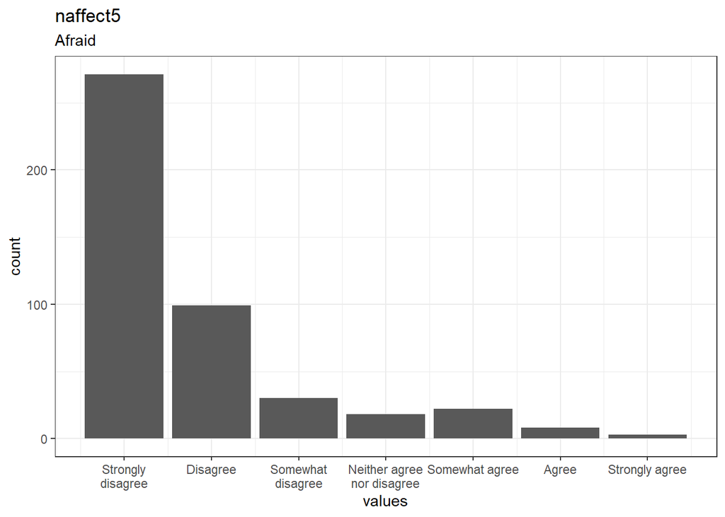

52 missing values.

#### Summary statistics

| name | label | data_type | value_labels | missing | complete | n | mean | sd | p0 | p25 | p50 | p75 | p100 | hist |
| --- | --- | --- | --- | --- | --- | --- | --- | --- | --- | --- | --- | --- | --- | --- |
| naffect5 | Afraid | numeric | 1. Strongly disagree, 2. Disagree, 3. Somewhat disagree, 4. Neither agree nor disagree, 5. Somewhat agree, 6. Agree, 7. Strongly agree | 52 | 451 | 503 | 1.8 | 1.3 | 1 | 1 | 1 | 2 | 7 | ▇▃▁▁▁▁▁▁ |

#### Value labels

- **Strongly disagree**: *1*
- **Disagree**: *2*
- **Somewhat disagree**: *3*
- **Neither agree nor disagree**: *4*
- **Somewhat agree**: *5*
- **Agree**: *6*
- **Strongly agree**: *7*

### naffect6

Angry

#### Distribution

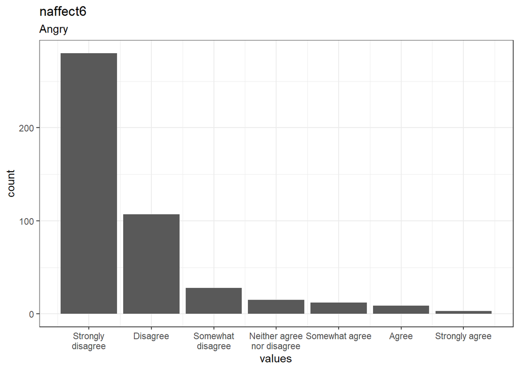

49 missing values.

#### Summary statistics

| name | label | data_type | value_labels | missing | complete | n | mean | sd | p0 | p25 | p50 | p75 | p100 | hist |
| --- | --- | --- | --- | --- | --- | --- | --- | --- | --- | --- | --- | --- | --- | --- |
| naffect6 | Angry | numeric | 1. Strongly disagree, 2. Disagree, 3. Somewhat disagree, 4. Neither agree nor disagree, 5. Somewhat agree, 6. Agree, 7. Strongly agree | 49 | 454 | 503 | 1.7 | 1.2 | 1 | 1 | 1 | 2 | 7 | ▇▃▁▁▁▁▁▁ |

#### Value labels

- **Strongly disagree**: *1*
- **Disagree**: *2*
- **Somewhat disagree**: *3*
- **Neither agree nor disagree**: *4*
- **Somewhat agree**: *5*
- **Agree**: *6*
- **Strongly agree**: *7*

### turnover1

If I have my own way, I will be working for my organization one year from now.

#### Distribution

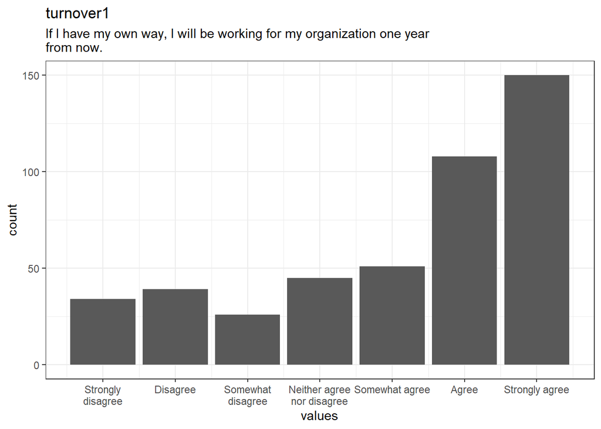

50 missing values.

#### Summary statistics

| name | label | data_type | value_labels | missing | complete | n | mean | sd | p0 | p25 | p50 | p75 | p100 | hist |
| --- | --- | --- | --- | --- | --- | --- | --- | --- | --- | --- | --- | --- | --- | --- |
| turnover1 | If I have my own way, I will be working for my organization one year from now. | numeric | 1. Strongly disagree, 2. Disagree, 3. Somewhat disagree, 4. Neither agree nor disagree, 5. Somewhat agree, 6. Agree, 7. Strongly agree | 50 | 453 | 503 | 5.13 | 1.96 | 1 | 4 | 6 | 7 | 7 | ▂▂▂▂▁▃▆▇ |

#### Value labels

- **Strongly disagree**: *1*
- **Disagree**: *2*
- **Somewhat disagree**: *3*
- **Neither agree nor disagree**: *4*
- **Somewhat agree**: *5*
- **Agree**: *6*
- **Strongly agree**: *7*

### turnover2

I frequently think of quitting my job.

#### Distribution

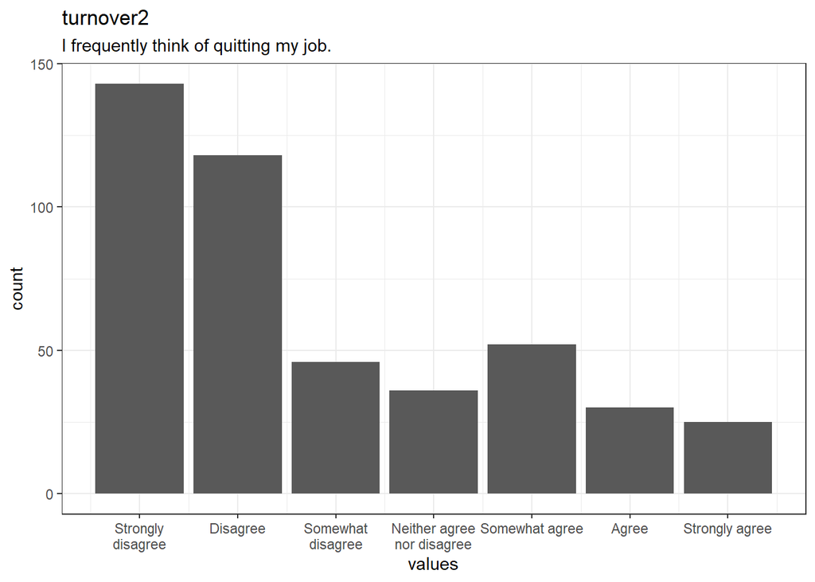

53 missing values.

#### Summary statistics

| name | label | data_type | value_labels | missing | complete | n | mean | sd | p0 | p25 | p50 | p75 | p100 | hist |
| --- | --- | --- | --- | --- | --- | --- | --- | --- | --- | --- | --- | --- | --- | --- |
| turnover2 | I frequently think of quitting my job. | numeric | 1. Strongly disagree, 2. Disagree, 3. Somewhat disagree, 4. Neither agree nor disagree, 5. Somewhat agree, 6. Agree, 7. Strongly agree | 53 | 450 | 503 | 2.84 | 1.88 | 1 | 1 | 2 | 4 | 7 | ▇▆▂▂▁▃▂▂ |

#### Value labels

- **Strongly disagree**: *1*
- **Disagree**: *2*
- **Somewhat disagree**: *3*
- **Neither agree nor disagree**: *4*
- **Somewhat agree**: *5*
- **Agree**: *6*
- **Strongly agree**: *7*

### turnover3

I am planning to search for a new job during the next 12 months.

#### Distribution

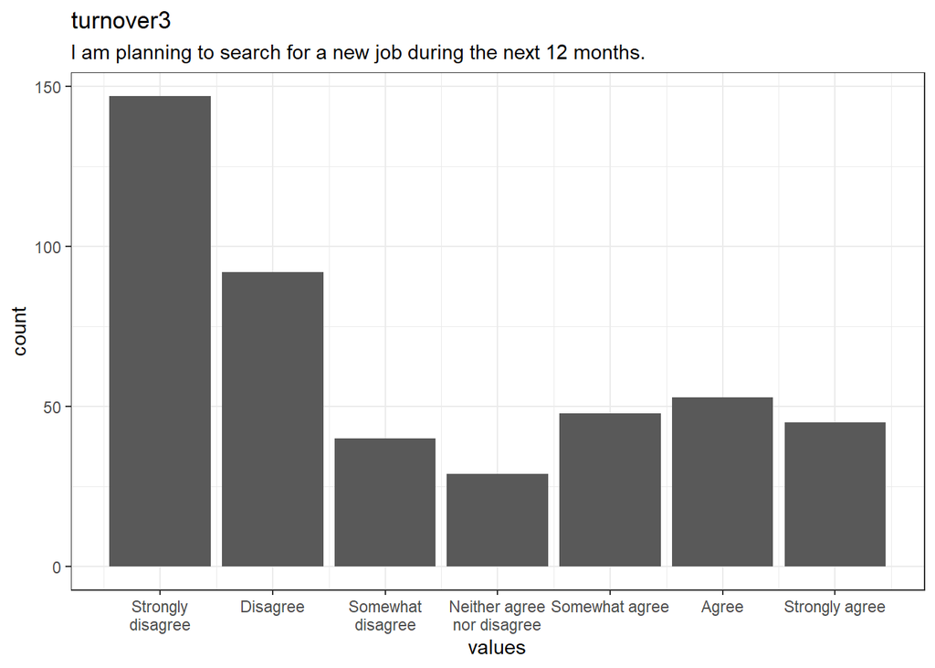

49 missing values.

#### Summary statistics

| name | label | data_type | value_labels | missing | complete | n | mean | sd | p0 | p25 | p50 | p75 | p100 | hist |
| --- | --- | --- | --- | --- | --- | --- | --- | --- | --- | --- | --- | --- | --- | --- |
| turnover3 | I am planning to search for a new job during the next 12 months. | numeric | 1. Strongly disagree, 2. Disagree, 3. Somewhat disagree, 4. Neither agree nor disagree, 5. Somewhat agree, 6. Agree, 7. Strongly agree | 49 | 454 | 503 | 3.17 | 2.15 | 1 | 1 | 2 | 5 | 7 | ▇▅▂▂▁▂▃▂ |

#### Value labels

- **Strongly disagree**: *1*
- **Disagree**: *2*
- **Somewhat disagree**: *3*
- **Neither agree nor disagree**: *4*
- **Somewhat agree**: *5*
- **Agree**: *6*
- **Strongly agree**: *7*

### prosocialimpact1

I am very conscious of the positive impact that my work has on others.

#### Distribution

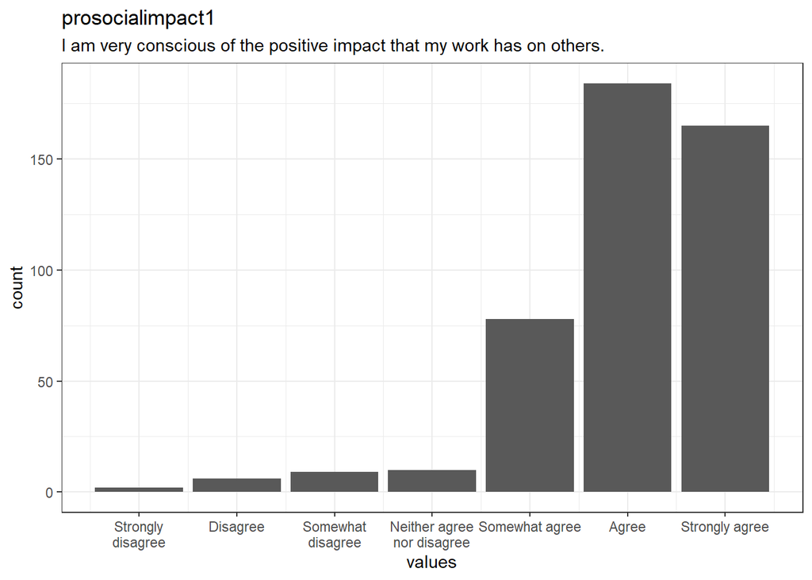

49 missing values.

#### Summary statistics

| name | label | data_type | value_labels | missing | complete | n | mean | sd | p0 | p25 | p50 | p75 | p100 | hist |
| --- | --- | --- | --- | --- | --- | --- | --- | --- | --- | --- | --- | --- | --- | --- |
| prosocialimpact1 | I am very conscious of the positive impact that my work has on others. | numeric | 1. Strongly disagree, 2. Disagree, 3. Somewhat disagree, 4. Neither agree nor disagree, 5. Somewhat agree, 6. Agree, 7. Strongly agree | 49 | 454 | 503 | 6.01 | 1.06 | 1 | 6 | 6 | 7 | 7 | ▁▁▁▁▁▃▇▇ |

#### Value labels

- **Strongly disagree**: *1*
- **Disagree**: *2*
- **Somewhat disagree**: *3*
- **Neither agree nor disagree**: *4*
- **Somewhat agree**: *5*
- **Agree**: *6*
- **Strongly agree**: *7*

### prosocialimpact2

I am very aware of the ways in which my work is benefiting others.

#### Distribution

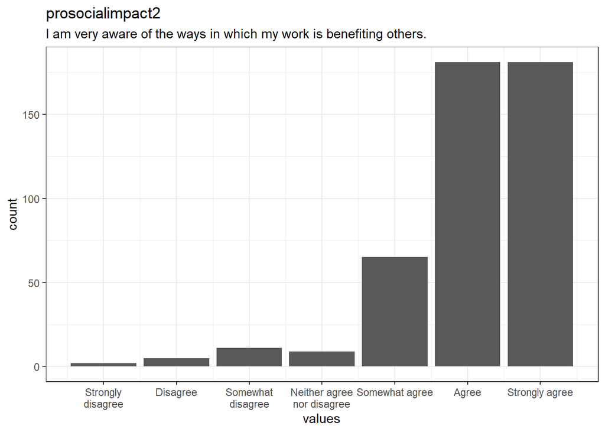

49 missing values.

#### Summary statistics

| name | label | data_type | value_labels | missing | complete | n | mean | sd | p0 | p25 | p50 | p75 | p100 | hist |
| --- | --- | --- | --- | --- | --- | --- | --- | --- | --- | --- | --- | --- | --- | --- |
| prosocialimpact2 | I am very aware of the ways in which my work is benefiting others. | numeric | 1. Strongly disagree, 2. Disagree, 3. Somewhat disagree, 4. Neither agree nor disagree, 5. Somewhat agree, 6. Agree, 7. Strongly agree | 49 | 454 | 503 | 6.08 | 1.06 | 1 | 6 | 6 | 7 | 7 | ▁▁▁▁▁▃▇▇ |

#### Value labels

- **Strongly disagree**: *1*
- **Disagree**: *2*
- **Somewhat disagree**: *3*
- **Neither agree nor disagree**: *4*
- **Somewhat agree**: *5*
- **Agree**: *6*
- **Strongly agree**: *7*

### prosocialimpact3

I feel that I can have a positive impact on others through my work.

#### Distribution

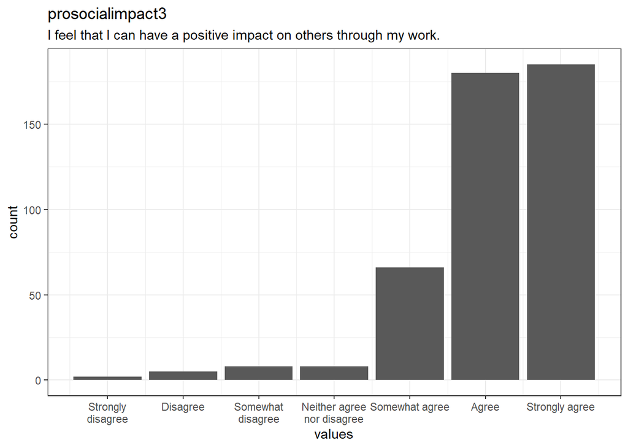

49 missing values.

#### Summary statistics

| name | label | data_type | value_labels | missing | complete | n | mean | sd | p0 | p25 | p50 | p75 | p100 | hist |
| --- | --- | --- | --- | --- | --- | --- | --- | --- | --- | --- | --- | --- | --- | --- |
| prosocialimpact3 | I feel that I can have a positive impact on others through my work. | numeric | 1. Strongly disagree, 2. Disagree, 3. Somewhat disagree, 4. Neither agree nor disagree, 5. Somewhat agree, 6. Agree, 7. Strongly agree | 49 | 454 | 503 | 6.11 | 1.03 | 1 | 6 | 6 | 7 | 7 | ▁▁▁▁▁▃▇▇ |

#### Value labels

- **Strongly disagree**: *1*
- **Disagree**: *2*
- **Somewhat disagree**: *3*
- **Neither agree nor disagree**: *4*
- **Somewhat agree**: *5*
- **Agree**: *6*
- **Strongly agree**: *7*

### manipulationcheck

Think about the beginning of the survey and the formulation of the first question regarding the content of your job: What exactly did we ask you to reflect upon?

#### Distribution

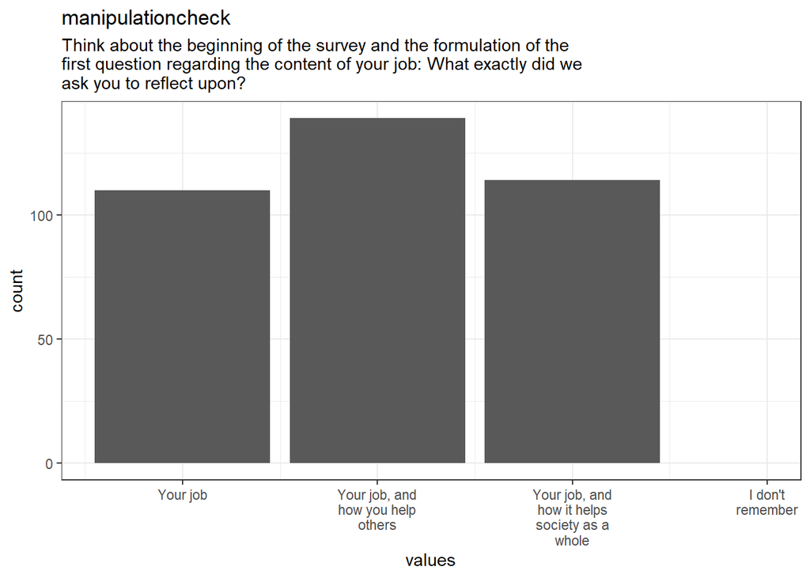

140 missing values.

#### Summary statistics

| name | label | data_type | value_labels | missing | complete | n | mean | sd | p0 | p25 | p50 | p75 | p100 | hist |
| --- | --- | --- | --- | --- | --- | --- | --- | --- | --- | --- | --- | --- | --- | --- |
| manipulationcheck | Think about the beginning of the survey and the formulation of the first question regarding the content of your job: What exactly did we ask you to reflect upon? | numeric | 1. Your job, 2. Your job, and how you help others, 3. Your job, and how it helps society as a whole, 4. I don’t remember | 140 | 363 | 503 | 2.01 | 0.79 | 1 | 1 | 2 | 3 | 3 | ▆▁▁▇▁▁▁▆ |

#### Value labels

- **Your job**: *1*
- **Your job, and how you help others**: *2*
- **Your job, and how it helps society as a whole**: *3*
- **I don’t remember**: *4*

### taskvariety1

To what extent would you say that your work is routine?

#### Distribution

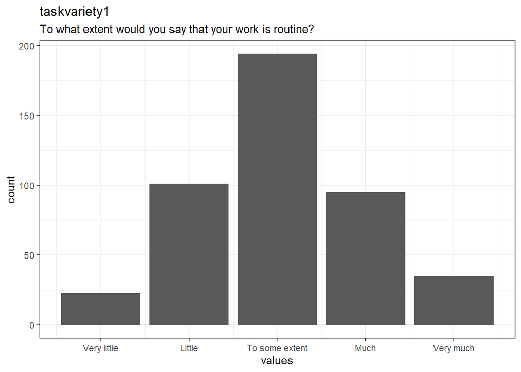

55 missing values.

#### Summary statistics

| name | label | data_type | value_labels | missing | complete | n | mean | sd | p0 | p25 | p50 | p75 | p100 | hist |
| --- | --- | --- | --- | --- | --- | --- | --- | --- | --- | --- | --- | --- | --- | --- |
| taskvariety1 | To what extent would you say that your work is routine? | numeric | 1. Very little, 2. Little, 3. To some extent, 4. Much, 5. Very much | 55 | 448 | 503 | 3.04 | 0.98 | 1 | 2 | 3 | 4 | 5 | ▁▅▁▇▁▃▁▂ |

#### Value labels

- **Very little**: *1*
- **Little**: *2*
- **To some extent**: *3*
- **Much**: *4*
- **Very much**: *5*

### taskvariety2

To what extent do you perform repetitive activities in your job?

#### Distribution

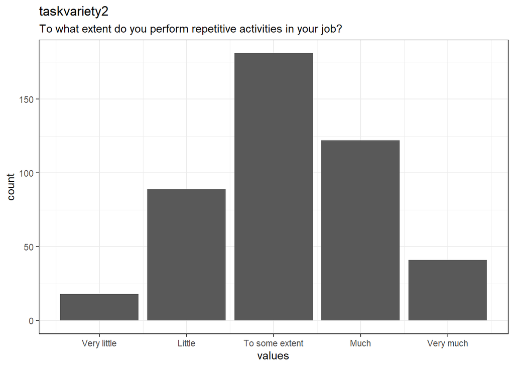

52 missing values.

#### Summary statistics

| name | label | data_type | value_labels | missing | complete | n | mean | sd | p0 | p25 | p50 | p75 | p100 | hist |
| --- | --- | --- | --- | --- | --- | --- | --- | --- | --- | --- | --- | --- | --- | --- |
| taskvariety2 | To what extent do you perform repetitive activities in your job? | numeric | 1. Very little, 2. Little, 3. To some extent, 4. Much, 5. Very much | 52 | 451 | 503 | 3.18 | 0.98 | 1 | 3 | 3 | 4 | 5 | ▁▃▁▇▁▆▁▂ |

#### Value labels

- **Very little**: *1*
- **Little**: *2*
- **To some extent**: *3*
- **Much**: *4*
- **Very much**: *5*

### taskvariety3

To what extent are your job duties repetitive?

#### Distribution

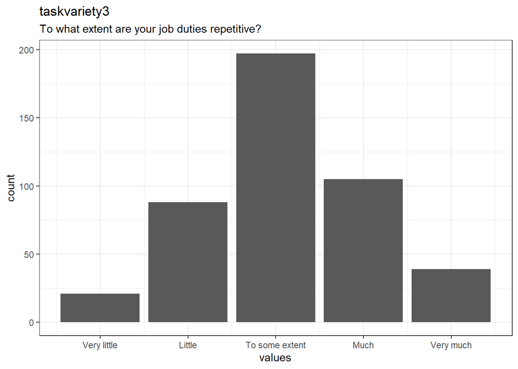

53 missing values.

#### Summary statistics

| name | label | data_type | value_labels | missing | complete | n | mean | sd | p0 | p25 | p50 | p75 | p100 | hist |
| --- | --- | --- | --- | --- | --- | --- | --- | --- | --- | --- | --- | --- | --- | --- |
| taskvariety3 | To what extent are your job duties repetitive? | numeric | 1. Very little, 2. Little, 3. To some extent, 4. Much, 5. Very much | 53 | 450 | 503 | 3.12 | 0.97 | 1 | 3 | 3 | 4 | 5 | ▁▃▁▇▁▅▁▂ |

#### Value labels

- **Very little**: *1*
- **Little**: *2*
- **To some extent**: *3*
- **Much**: *4*
- **Very much**: *5*

### taskvariety4

To what extent are your job tasks the same day-to-day?

#### Distribution

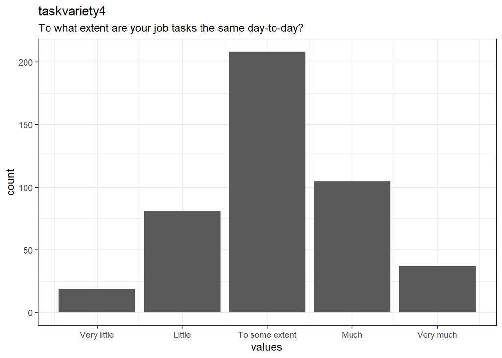

53 missing values.

#### Summary statistics

| name | label | data_type | value_labels | missing | complete | n | mean | sd | p0 | p25 | p50 | p75 | p100 | hist |
| --- | --- | --- | --- | --- | --- | --- | --- | --- | --- | --- | --- | --- | --- | --- |
| taskvariety4 | To what extent are your job tasks the same day-to-day? | numeric | 1. Very little, 2. Little, 3. To some extent, 4. Much, 5. Very much | 53 | 450 | 503 | 3.13 | 0.95 | 1 | 3 | 3 | 4 | 5 | ▁▃▁▇▁▅▁▂ |

#### Value labels

- **Very little**: *1*
- **Little**: *2*
- **To some extent**: *3*
- **Much**: *4*
- **Very much**: *5*

### taskvariety5

To what extend do you do about the same job in the same way most of the time?

#### Distribution

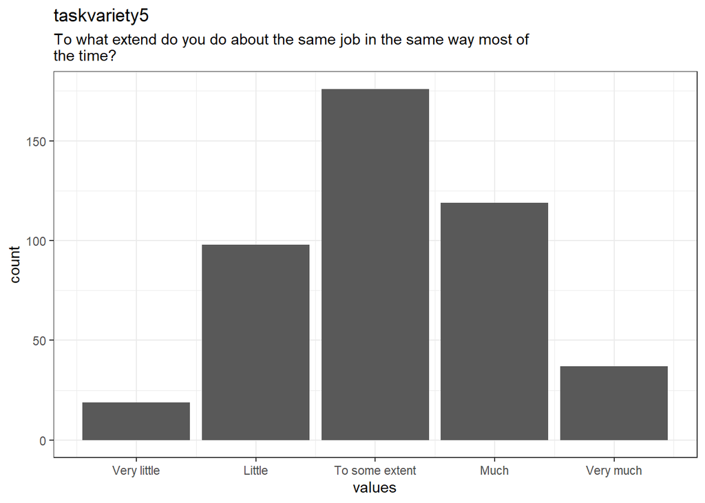

54 missing values.

#### Summary statistics

| name | label | data_type | value_labels | missing | complete | n | mean | sd | p0 | p25 | p50 | p75 | p100 | hist |
| --- | --- | --- | --- | --- | --- | --- | --- | --- | --- | --- | --- | --- | --- | --- |
| taskvariety5 | To what extend do you do about the same job in the same way most of the time? | numeric | 1. Very little, 2. Little, 3. To some extent, 4. Much, 5. Very much | 54 | 449 | 503 | 3.13 | 0.98 | 1 | 2 | 3 | 4 | 5 | ▁▅▁▇▁▆▁▂ |

#### Value labels

- **Very little**: *1*
- **Little**: *2*
- **To some extent**: *3*
- **Much**: *4*
- **Very much**: *5*

### taskanalyz1

To what extent is there a clearly known way to do the major types of work you normally encounter?

#### Distribution

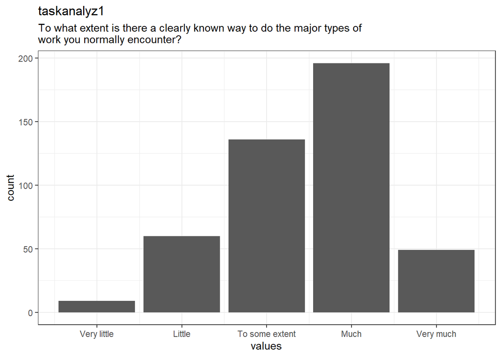

53 missing values.

#### Summary statistics

| name | label | data_type | value_labels | missing | complete | n | mean | sd | p0 | p25 | p50 | p75 | p100 | hist |
| --- | --- | --- | --- | --- | --- | --- | --- | --- | --- | --- | --- | --- | --- | --- |
| taskanalyz1 | To what extent is there a clearly known way to do the major types of work you normally encounter? | numeric | 1. Very little, 2. Little, 3. To some extent, 4. Much, 5. Very much | 53 | 450 | 503 | 3.48 | 0.93 | 1 | 3 | 4 | 4 | 5 | ▁▂▁▆▁▇▁▂ |

#### Value labels

- **Very little**: *1*
- **Little**: *2*
- **To some extent**: *3*
- **Much**: *4*
- **Very much**: *5*

### taskanalyz2

To what extent is there a clearly defined body of knowledge of subject matter that can guide you in doing your work?

#### Distribution

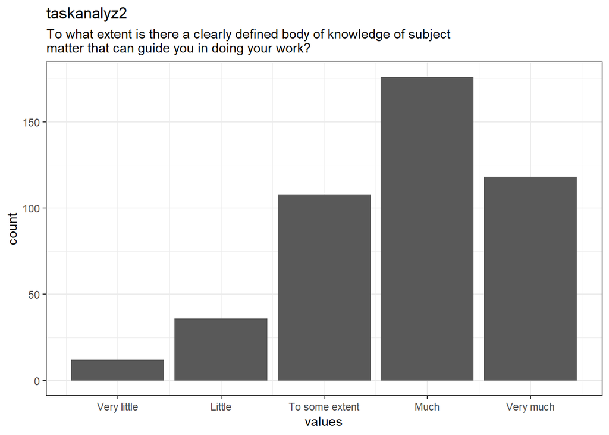

53 missing values.

#### Summary statistics

| name | label | data_type | value_labels | missing | complete | n | mean | sd | p0 | p25 | p50 | p75 | p100 | hist |
| --- | --- | --- | --- | --- | --- | --- | --- | --- | --- | --- | --- | --- | --- | --- |
| taskanalyz2 | To what extent is there a clearly defined body of knowledge of subject matter that can guide you in doing your work? | numeric | 1. Very little, 2. Little, 3. To some extent, 4. Much, 5. Very much | 53 | 450 | 503 | 3.78 | 1.01 | 1 | 3 | 4 | 5 | 5 | ▁▂▁▅▁▇▁▆ |

#### Value labels

- **Very little**: *1*
- **Little**: *2*
- **To some extent**: *3*
- **Much**: *4*
- **Very much**: *5*

### taskanalyz3

To what extent is there an understandable sequence of steps that can be followed in doing your work?

#### Distribution

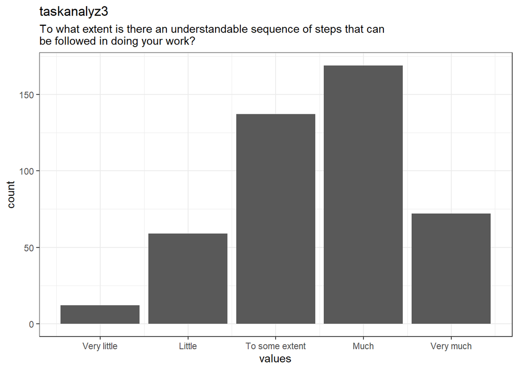

54 missing values.

#### Summary statistics

| name | label | data_type | value_labels | missing | complete | n | mean | sd | p0 | p25 | p50 | p75 | p100 | hist |
| --- | --- | --- | --- | --- | --- | --- | --- | --- | --- | --- | --- | --- | --- | --- |
| taskanalyz3 | To what extent is there an understandable sequence of steps that can be followed in doing your work? | numeric | 1. Very little, 2. Little, 3. To some extent, 4. Much, 5. Very much | 54 | 449 | 503 | 3.51 | 1 | 1 | 3 | 4 | 4 | 5 | ▁▃▁▆▁▇▁▃ |

#### Value labels

- **Very little**: *1*
- **Little**: *2*
- **To some extent**: *3*
- **Much**: *4*
- **Very much**: *5*

### taskanalyz4

To what extent can you actually rely on established procedures and practices to do your work?

#### Distribution

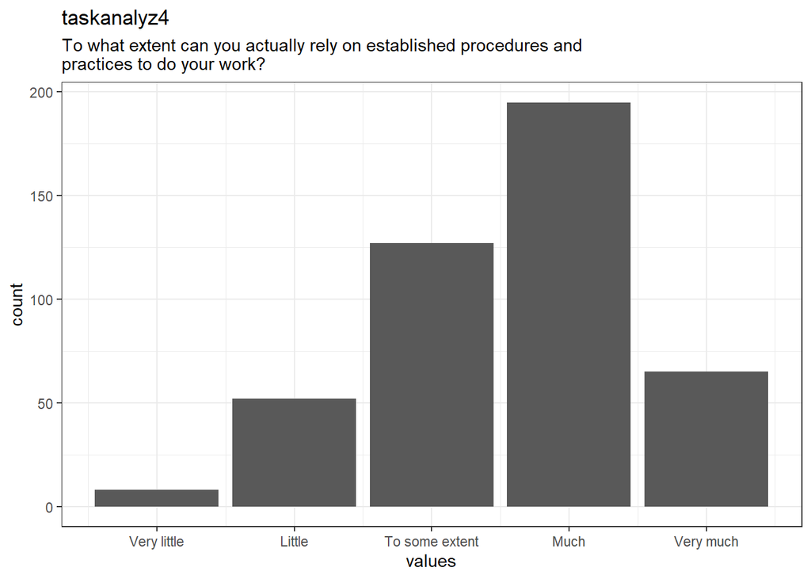

56 missing values.

#### Summary statistics

| name | label | data_type | value_labels | missing | complete | n | mean | sd | p0 | p25 | p50 | p75 | p100 | hist |
| --- | --- | --- | --- | --- | --- | --- | --- | --- | --- | --- | --- | --- | --- | --- |
| taskanalyz4 | To what extent can you actually rely on established procedures and practices to do your work? | numeric | 1. Very little, 2. Little, 3. To some extent, 4. Much, 5. Very much | 56 | 447 | 503 | 3.57 | 0.94 | 1 | 3 | 4 | 4 | 5 | ▁▂▁▅▁▇▁▂ |

#### Value labels

- **Very little**: *1*
- **Little**: *2*
- **To some extent**: *3*
- **Much**: *4*
- **Very much**: *5*

### attention1

Please answer ‘the middle option’ here (‘To Some Extent’)

#### Distribution

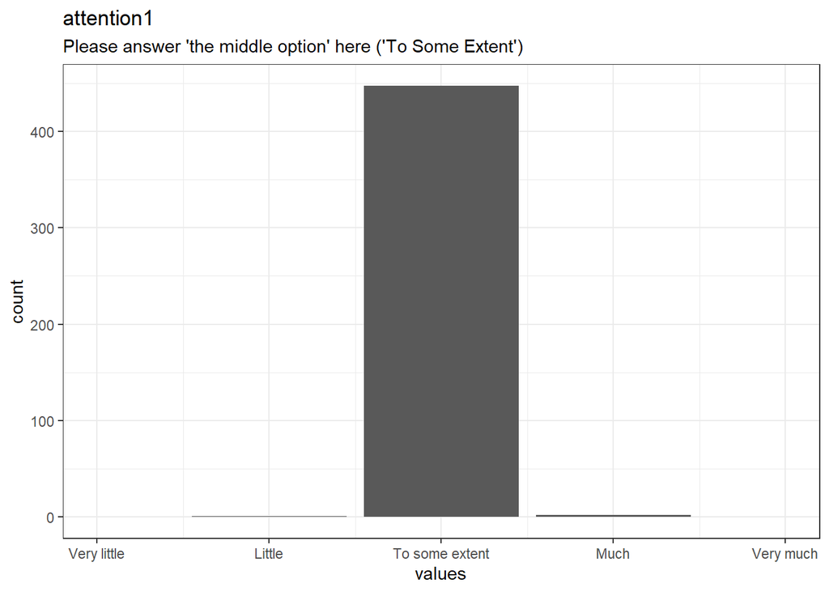

53 missing values.

#### Summary statistics

| name | label | data_type | value_labels | missing | complete | n | mean | sd | p0 | p25 | p50 | p75 | p100 | hist |
| --- | --- | --- | --- | --- | --- | --- | --- | --- | --- | --- | --- | --- | --- | --- |
| attention1 | Please answer ‘the middle option’ here (‘To Some Extent’) | numeric | 1. Very little, 2. Little, 3. To some extent, 4. Much, 5. Very much | 53 | 450 | 503 | 3 | 0.082 | 2 | 3 | 3 | 3 | 4 | ▁▁▁▇▁▁▁▁ |

#### Value labels

- **Very little**: *1*
- **Little**: *2*
- **To some extent**: *3*
- **Much**: *4*
- **Very much**: *5*

### autonomy1

I have significant autonomy in determining how I do my job.

#### Distribution

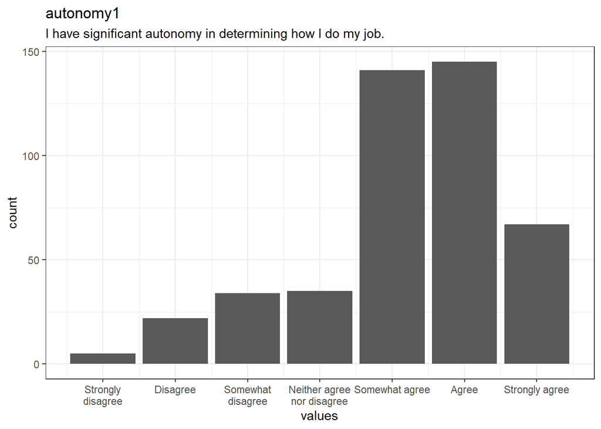

54 missing values.

#### Summary statistics

| name | label | data_type | value_labels | missing | complete | n | mean | sd | p0 | p25 | p50 | p75 | p100 | hist |
| --- | --- | --- | --- | --- | --- | --- | --- | --- | --- | --- | --- | --- | --- | --- |
| autonomy1 | I have significant autonomy in determining how I do my job. | numeric | 1. Strongly disagree, 2. Disagree, 3. Somewhat disagree, 4. Neither agree nor disagree, 5. Somewhat agree, 6. Agree, 7. Strongly agree | 54 | 449 | 503 | 5.2 | 1.37 | 1 | 5 | 5 | 6 | 7 | ▁▁▂▂▁▇▇▃ |

#### Value labels

- **Strongly disagree**: *1*
- **Disagree**: *2*
- **Somewhat disagree**: *3*
- **Neither agree nor disagree**: *4*
- **Somewhat agree**: *5*
- **Agree**: *6*
- **Strongly agree**: *7*

### autonomy2

I can decide on my own how to go about doing my work.

#### Distribution

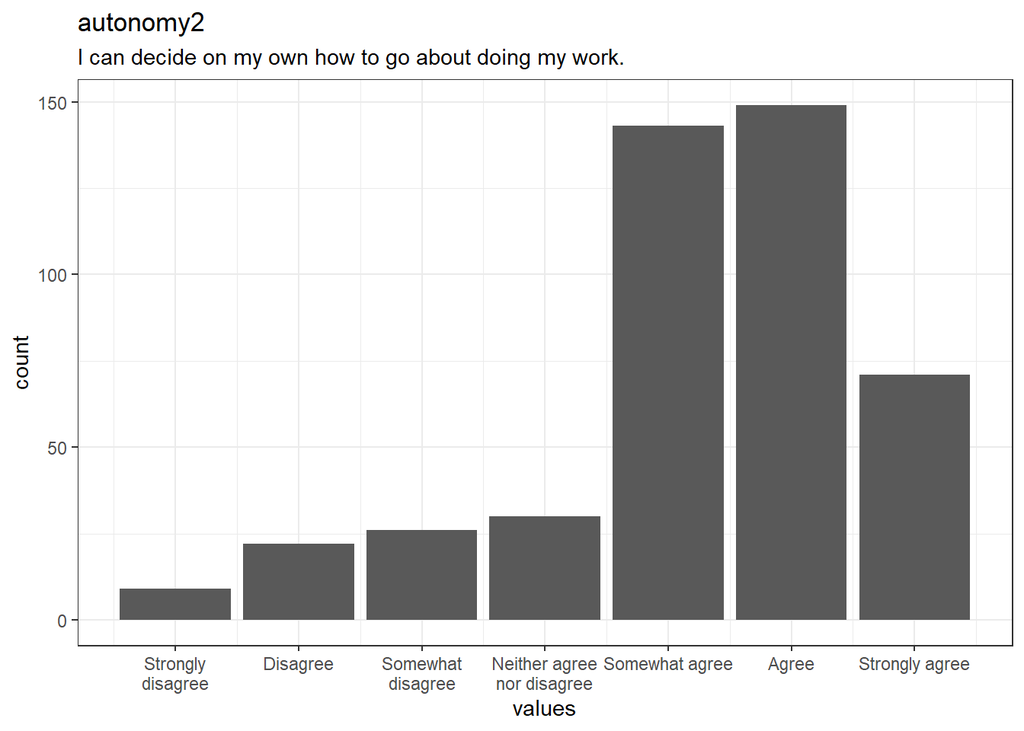

53 missing values.

#### Summary statistics

| name | label | data_type | value_labels | missing | complete | n | mean | sd | p0 | p25 | p50 | p75 | p100 | hist |
| --- | --- | --- | --- | --- | --- | --- | --- | --- | --- | --- | --- | --- | --- | --- |
| autonomy2 | I can decide on my own how to go about doing my work. | numeric | 1. Strongly disagree, 2. Disagree, 3. Somewhat disagree, 4. Neither agree nor disagree, 5. Somewhat agree, 6. Agree, 7. Strongly agree | 53 | 450 | 503 | 5.24 | 1.4 | 1 | 5 | 5 | 6 | 7 | ▁▁▂▂▁▇▇▃ |

#### Value labels

- **Strongly disagree**: *1*
- **Disagree**: *2*
- **Somewhat disagree**: *3*
- **Neither agree nor disagree**: *4*
- **Somewhat agree**: *5*
- **Agree**: *6*
- **Strongly agree**: *7*

### autonomy3

I have considerable opportunity for independence and freedom in how I do my job.

#### Distribution

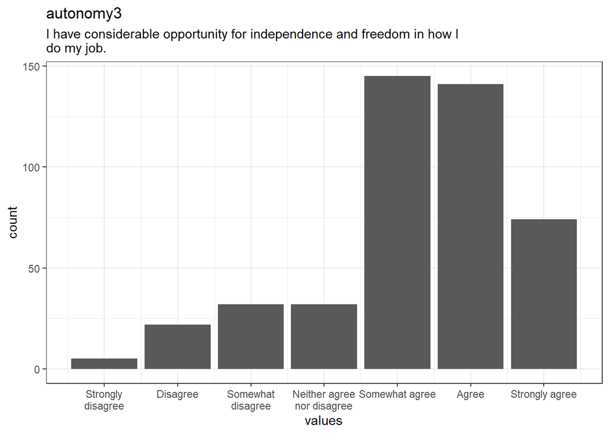

52 missing values.

#### Summary statistics

| name | label | data_type | value_labels | missing | complete | n | mean | sd | p0 | p25 | p50 | p75 | p100 | hist |
| --- | --- | --- | --- | --- | --- | --- | --- | --- | --- | --- | --- | --- | --- | --- |
| autonomy3 | I have considerable opportunity for independence and freedom in how I do my job. | numeric | 1. Strongly disagree, 2. Disagree, 3. Somewhat disagree, 4. Neither agree nor disagree, 5. Somewhat agree, 6. Agree, 7. Strongly agree | 52 | 451 | 503 | 5.24 | 1.37 | 1 | 5 | 5 | 6 | 7 | ▁▁▂▂▁▇▇▅ |

#### Value labels

- **Strongly disagree**: *1*
- **Disagree**: *2*
- **Somewhat disagree**: *3*
- **Neither agree nor disagree**: *4*
- **Somewhat agree**: *5*
- **Agree**: *6*
- **Strongly agree**: *7*

### beneficiaries1

My job gives me the opportunity to meet the people who benefit from my work .

#### Distribution

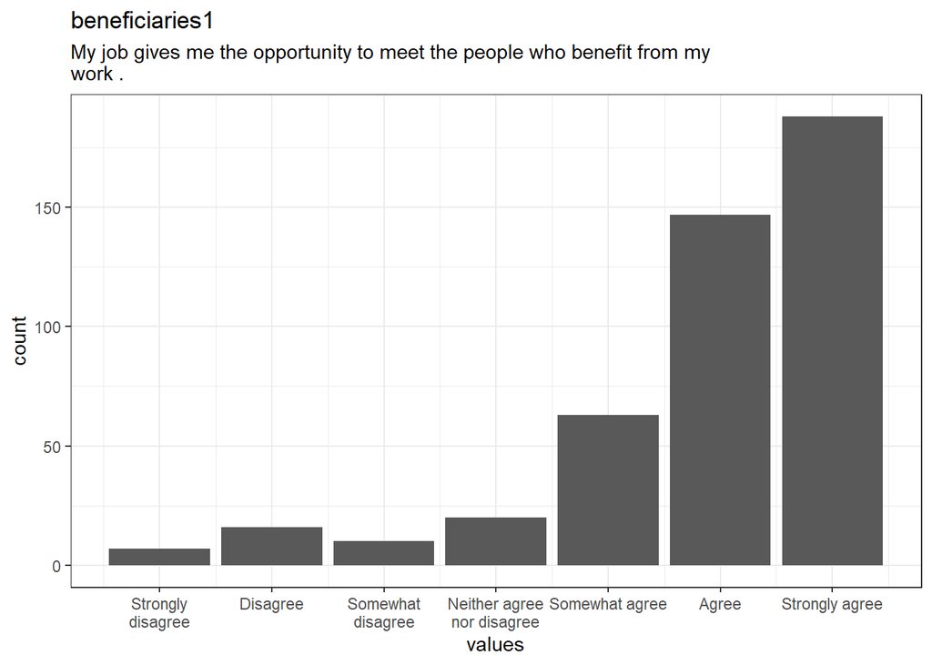

52 missing values.

#### Summary statistics

| name | label | data_type | value_labels | missing | complete | n | mean | sd | p0 | p25 | p50 | p75 | p100 | hist |
| --- | --- | --- | --- | --- | --- | --- | --- | --- | --- | --- | --- | --- | --- | --- |
| beneficiaries1 | My job gives me the opportunity to meet the people who benefit from my work . | numeric | 1. Strongly disagree, 2. Disagree, 3. Somewhat disagree, 4. Neither agree nor disagree, 5. Somewhat agree, 6. Agree, 7. Strongly agree | 52 | 451 | 503 | 5.9 | 1.37 | 1 | 5 | 6 | 7 | 7 | ▁▁▁▁▁▃▆▇ |

#### Value labels

- **Strongly disagree**: *1*
- **Disagree**: *2*
- **Somewhat disagree**: *3*
- **Neither agree nor disagree**: *4*
- **Somewhat agree**: *5*
- **Agree**: *6*
- **Strongly agree**: *7*

### beneficiaries2

My job provides me with contact with the people who benefit from my work.

#### Distribution

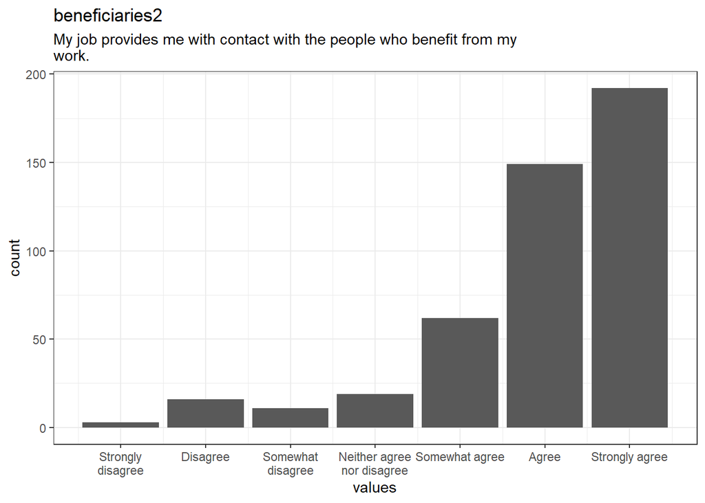

51 missing values.

#### Summary statistics

| name | label | data_type | value_labels | missing | complete | n | mean | sd | p0 | p25 | p50 | p75 | p100 | hist |
| --- | --- | --- | --- | --- | --- | --- | --- | --- | --- | --- | --- | --- | --- | --- |
| beneficiaries2 | My job provides me with contact with the people who benefit from my work. | numeric | 1. Strongly disagree, 2. Disagree, 3. Somewhat disagree, 4. Neither agree nor disagree, 5. Somewhat agree, 6. Agree, 7. Strongly agree | 51 | 452 | 503 | 5.96 | 1.3 | 1 | 6 | 6 | 7 | 7 | ▁▁▁▁▁▂▆▇ |

#### Value labels

- **Strongly disagree**: *1*
- **Disagree**: *2*
- **Somewhat disagree**: *3*
- **Neither agree nor disagree**: *4*
- **Somewhat agree**: *5*
- **Agree**: *6*
- **Strongly agree**: *7*

### attention2

Please answer ‘strongly disagree’ here.

#### Distribution

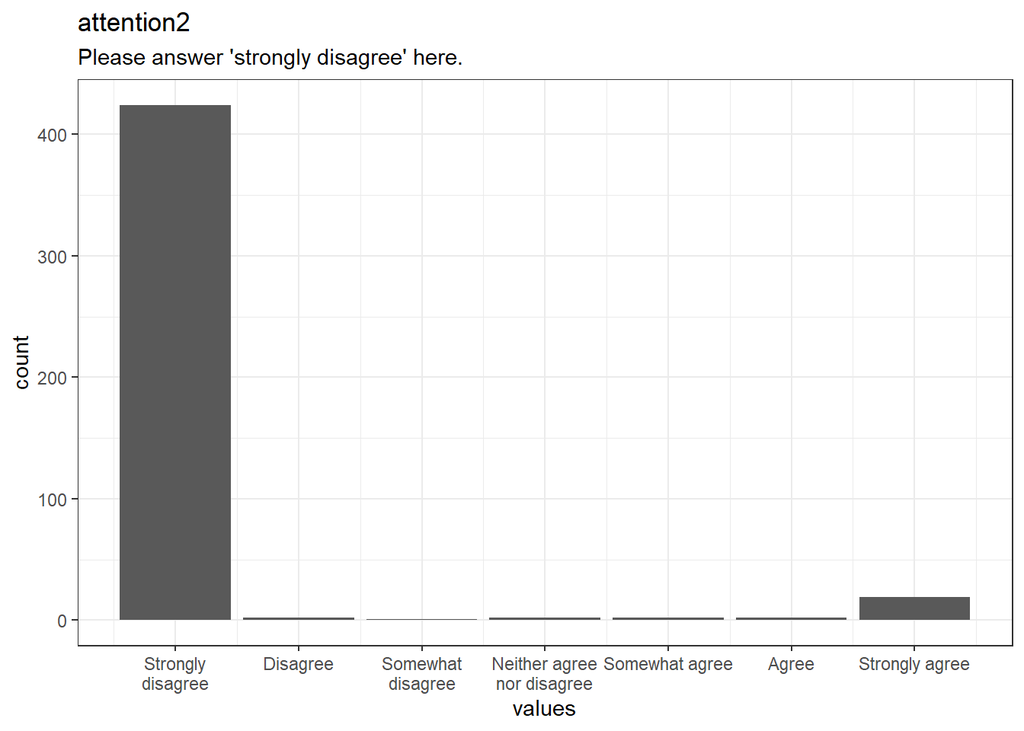

51 missing values.

#### Summary statistics

| name | label | data_type | value_labels | missing | complete | n | mean | sd | p0 | p25 | p50 | p75 | p100 | hist |
| --- | --- | --- | --- | --- | --- | --- | --- | --- | --- | --- | --- | --- | --- | --- |
| attention2 | Please answer ‘strongly disagree’ here. | numeric | 1. Strongly disagree, 2. Disagree, 3. Somewhat disagree, 4. Neither agree nor disagree, 5. Somewhat agree, 6. Agree, 7. Strongly agree | 51 | 452 | 503 | 1.31 | 1.29 | 1 | 1 | 1 | 1 | 7 | ▇▁▁▁▁▁▁▁ |

#### Value labels

- **Strongly disagree**: *1*
- **Disagree**: *2*
- **Somewhat disagree**: *3*
- **Neither agree nor disagree**: *4*
- **Somewhat agree**: *5*
- **Agree**: *6*
- **Strongly agree**: *7*

### manager

Are you responsible for the management of other colleagues / employees (i.e. are you a manager)? Please indicate the number of employees.

#### Distribution

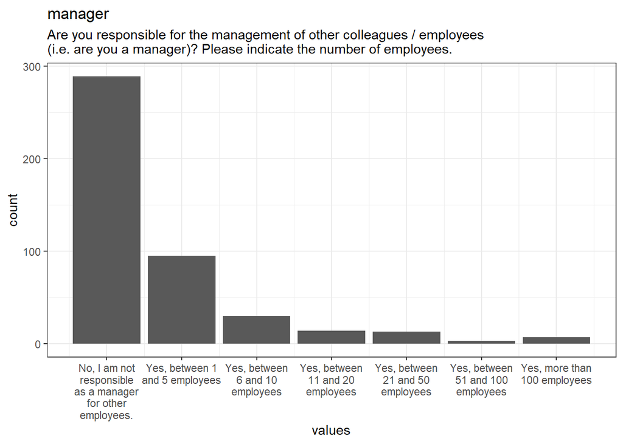

52 missing values.

#### Summary statistics

| name | label | data_type | value_labels | missing | complete | n | mean | sd | p0 | p25 | p50 | p75 | p100 | hist |
| --- | --- | --- | --- | --- | --- | --- | --- | --- | --- | --- | --- | --- | --- | --- |
| manager | Are you responsible for the management of other colleagues / employees (i.e. are you a manager)? Please indicate the number of employees. | numeric | 0. No, I am not responsible as a manager for other employees., 1. Yes, between 1 and 5 employees, 2. Yes, between 6 and 10 employees, 3. Yes, between 11 and 20 employees, 4. Yes, between 21 and 50 emp… | 52 | 451 | 503 | 0.68 | 1.22 | 0 | 0 | 0 | 1 | 6 | ▇▂▁▁▁▁▁▁ |

#### Value labels

- **No, I am not responsible as a manager for other employees.**: *0*
- **Yes, between 1 and 5 employees**: *1*
- **Yes, between 6 and 10 employees**: *2*
- **Yes, between 11 and 20 employees**: *3*
- **Yes, between 21 and 50 employees**: *4*
- **Yes, between 51 and 100 employees**: *5*
- **Yes, more than 100 employees**: *6*

### gender

What is your gender?

#### Distribution

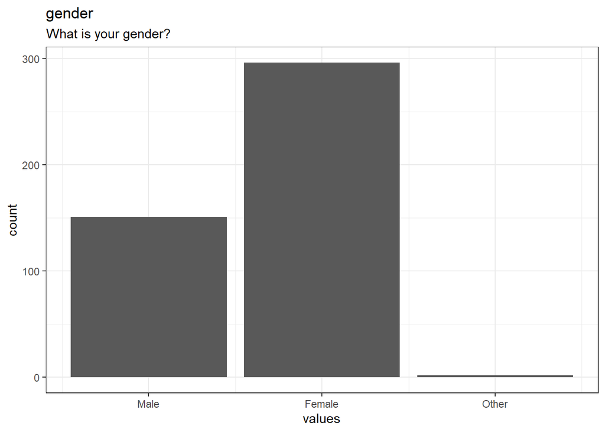

54 missing values.

#### Summary statistics

| name | label | data_type | value_labels | missing | complete | n | mean | sd | p0 | p25 | p50 | p75 | p100 | hist |
| --- | --- | --- | --- | --- | --- | --- | --- | --- | --- | --- | --- | --- | --- | --- |
| gender | What is your gender? | numeric | 0. Male, 1. Female, 2. Other | 54 | 449 | 503 | 0.67 | 0.48 | 0 | 0 | 1 | 1 | 2 | ▅▁▁▇▁▁▁▁ |

#### Value labels

- **Male**: *0*
- **Female**: *1*
- **Other**: *2*

### yearbirth

What year were you born?

#### Distribution

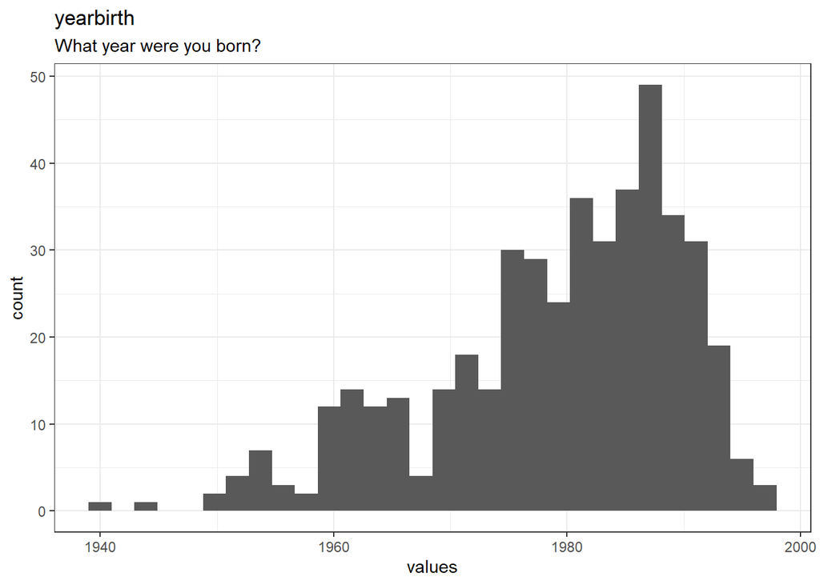

53 missing values.

#### Summary statistics

| name | label | data_type | missing | complete | n | mean | sd | p0 | p25 | p50 | p75 | p100 | hist |
| --- | --- | --- | --- | --- | --- | --- | --- | --- | --- | --- | --- | --- | --- |
| yearbirth | What year were you born? | numeric | 53 | 450 | 503 | 1979.4 | 10.9 | 1940 | 1973 | 1982 | 1988 | 1997 | ▁▁▂▂▃▆▇▅ |

### educator

Do you work as an Educator?

#### Distribution

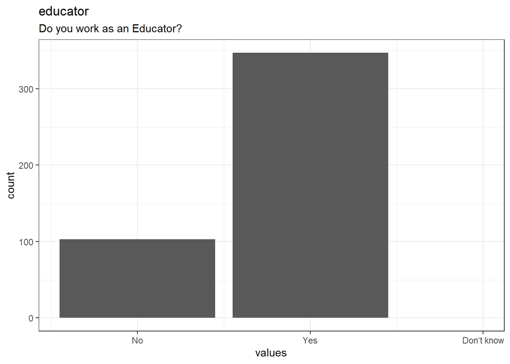

53 missing values.

#### Summary statistics

| name | label | data_type | value_labels | missing | complete | n | mean | sd | p0 | p25 | p50 | p75 | p100 | hist |
| --- | --- | --- | --- | --- | --- | --- | --- | --- | --- | --- | --- | --- | --- | --- |
| educator | Do you work as an Educator? | numeric | 0. No, 1. Yes, 2. Don‘t know | 53 | 450 | 503 | 0.77 | 0.42 | 0 | 1 | 1 | 1 | 1 | ▂▁▁▁▁▁▁▇ |

#### Value labels

- **No**: *0*
- **Yes**: *1*
- **Don‘t know**: *2*

### sector

In which sector do you work?

#### Distribution

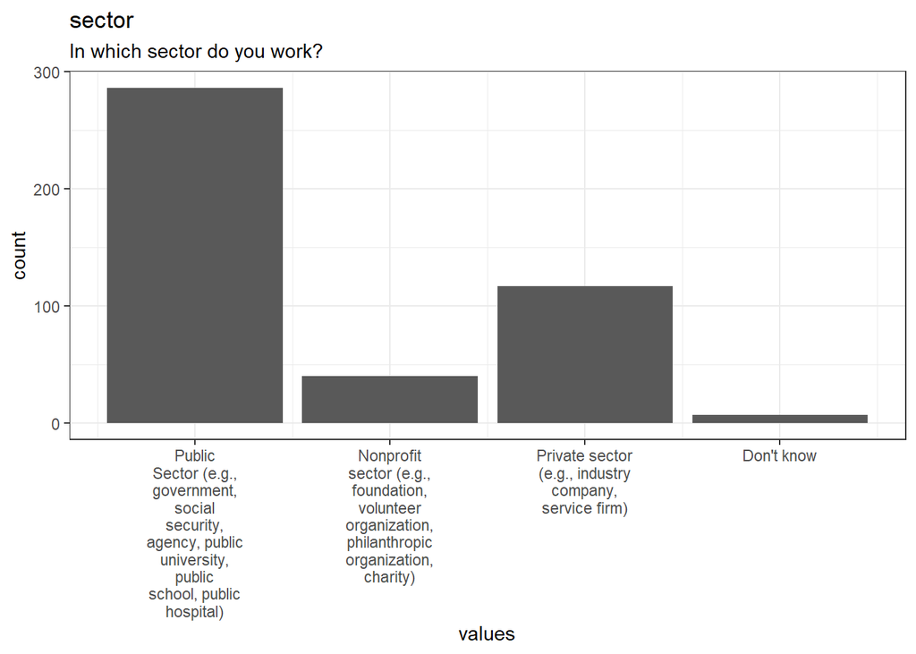

53 missing values.

#### Summary statistics

| name | label | data_type | value_labels | missing | complete | n | mean | sd | p0 | p25 | p50 | p75 | p100 | hist |
| --- | --- | --- | --- | --- | --- | --- | --- | --- | --- | --- | --- | --- | --- | --- |
| sector | In which sector do you work? | numeric | 1. Public Sector (e.g., government, social security, agency, public university, public school, public hospital), 2. Nonprofit sector (e.g., foundation, volunteer organization, philanthropic organizati… | 53 | 450 | 503 | 1.66 | 0.92 | 1 | 1 | 1 | 3 | 4 | ▇▁▁▁▁▃▁▁ |

#### Value labels

- **Public Sector (e.g., government, social security, agency, public university, public school, public hospital)**: *1*
- **Nonprofit sector (e.g., foundation, volunteer organization, philanthropic organization, charity)**: *2*
- **Private sector (e.g., industry company, service firm)**: *3*
- **Don’t know**: *4*

### subsector

Which part of the education sector are you working in?

#### Distribution

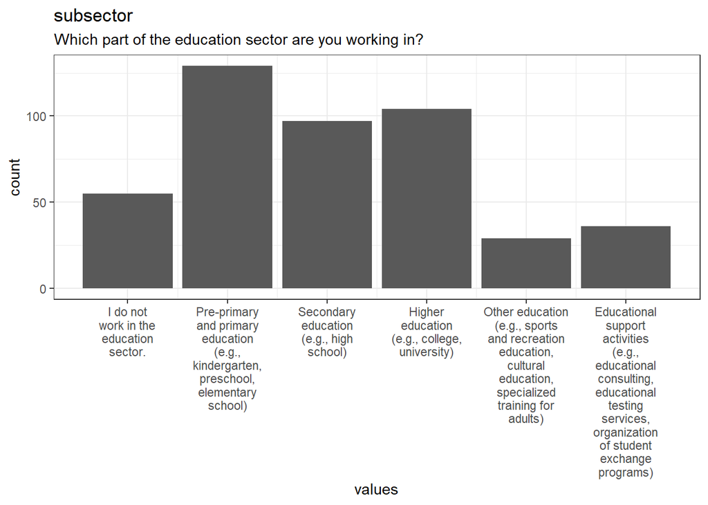

53 missing values.

#### Summary statistics

| name | label | data_type | value_labels | missing | complete | n | mean | sd | p0 | p25 | p50 | p75 | p100 | hist |
| --- | --- | --- | --- | --- | --- | --- | --- | --- | --- | --- | --- | --- | --- | --- |
| subsector | Which part of the education sector are you working in? | numeric | 1. Pre-primary and primary education (e.g., kindergarten, preschool, elementary school), 2. Secondary education (e.g., high school), 3. Higher education (e.g., college, university), 4. Other education… | 53 | 450 | 503 | 2.07 | 1.41 | 0 | 1 | 2 | 3 | 5 | ▃▇▁▆▆▁▂▂ |

#### Value labels

- **Pre-primary and primary education (e.g., kindergarten, preschool, elementary school)**: *1*
- **Secondary education (e.g., high school)**: *2*
- **Higher education (e.g., college, university)**: *3*
- **Other education (e.g., sports and recreation education, cultural education, specialized training for adults)**: *4*
- **Educational support activities (e.g., educational consulting, educational testing services, organization of student exchange programs)**: *5*
- **I do not work in the education sector.**: *0*

### atwork

Are you currently in your usual work environment?

#### Distribution

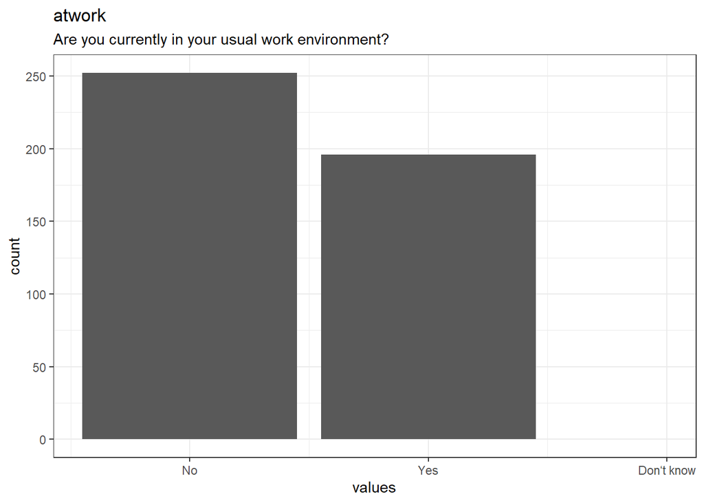

55 missing values.

#### Summary statistics

| name | label | data_type | value_labels | missing | complete | n | mean | sd | p0 | p25 | p50 | p75 | p100 | hist |
| --- | --- | --- | --- | --- | --- | --- | --- | --- | --- | --- | --- | --- | --- | --- |
| atwork | Are you currently in your usual work environment? | numeric | 0. No, 1. Yes, 2. Don‘t know | 55 | 448 | 503 | 0.44 | 0.5 | 0 | 0 | 0 | 1 | 1 | ▇▁▁▁▁▁▁▆ |

#### Value labels

- **No**: *0*
- **Yes**: *1*
- **Don‘t know**: *2*

### duration_treatment_general

Time participants spent for treatment (passive control)

#### Distribution

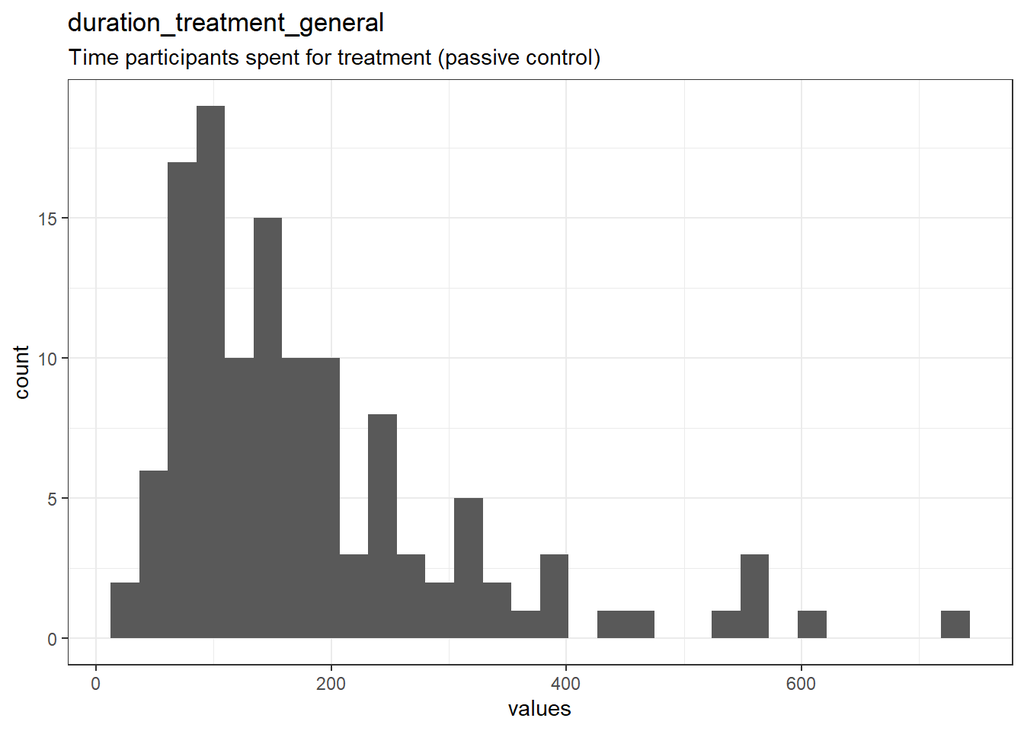

379 missing values.

#### Summary statistics

| name | label | data_type | missing | complete | n | mean | sd | p0 | p25 | p50 | p75 | p100 | hist |
| --- | --- | --- | --- | --- | --- | --- | --- | --- | --- | --- | --- | --- | --- |
| duration_treatment_general | Time participants spent for treatment (passive control) | numeric | 379 | 124 | 503 | 184.24 | 130.51 | 13.4 | 98.49 | 147.44 | 231.76 | 719.76 | ▆▇▃▂▁▁▁▁ |

### duration_treatment_prosocial

Time participants spent for treatment (prosocial impact)

#### Distribution

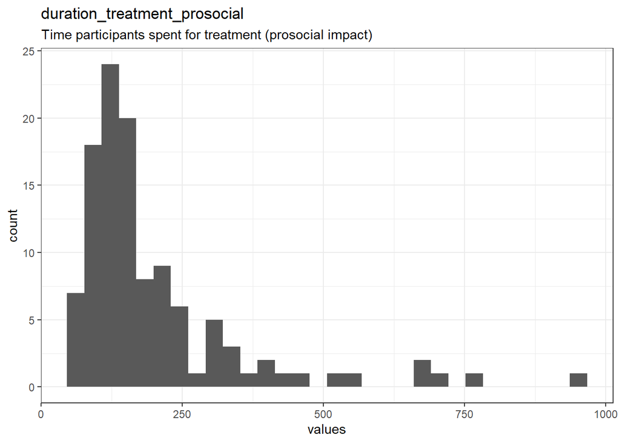

390 missing values.

#### Summary statistics

| name | label | data_type | missing | complete | n | mean | sd | p0 | p25 | p50 | p75 | p100 | hist |
| --- | --- | --- | --- | --- | --- | --- | --- | --- | --- | --- | --- | --- | --- |
| duration_treatment_prosocial | Time participants spent for treatment (prosocial impact) | numeric | 390 | 113 | 503 | 200.62 | 155.66 | 54.03 | 110.71 | 145.66 | 224.23 | 944.37 | ▇▃▁▁▁▁▁▁ |

### duration_treatment_societal

Time participants spent for treatment (societal impact)

#### Distribution

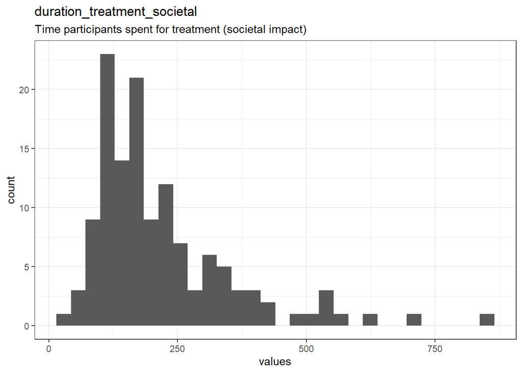

373 missing values.

#### Summary statistics

| name | label | data_type | missing | complete | n | mean | sd | p0 | p25 | p50 | p75 | p100 | hist |
| --- | --- | --- | --- | --- | --- | --- | --- | --- | --- | --- | --- | --- | --- |
| duration_treatment_societal | Time participants spent for treatment (societal impact) | numeric | 373 | 130 | 503 | 219.06 | 137.43 | 41.55 | 124.76 | 175.97 | 264.14 | 864.07 | ▇▇▃▁▁▁▁▁ |

## Codebook table

| name | label | data_type | value_labels | missing | complete | n | n_unique | median | min | max | mean | sd | p0 | p25 | p50 | p75 | p100 | hist |
| --- | --- | --- | --- | --- | --- | --- | --- | --- | --- | --- | --- | --- | --- | --- | --- | --- | --- | --- |
| id | ID | numeric |  | 0 | 503 | 503 |  |  |  |  | 252 | 145.35 | 1 | 126.5 | 252 | 377.5 | 503 | ▇▇▇▇▇▇▇▇ |
| startdate | Start Date | POSIXct |  | 0 | 503 | 503 | 503 | 2017-12-12 | 2017-12-11 | 2017-12-19 |  |  |  |  |  |  |  |  |
| submitdate | End Date | POSIXct |  | 53 | 450 | 503 | 450 | 2017-12-12 | 2017-12-11 | 2017-12-19 |  |  |  |  |  |  |  |  |
| lastpage | Last page of questionnaire finished | numeric |  | 0 | 503 | 503 |  |  |  |  | 10.2 | 2.39 | 2 | 11 | 11 | 11 | 11 | ▁▁▁▁▁▁▁▇ |
| treatment | Treatment group | numeric | 1. Passive Control,2. Active Control,3. Prosocial Impact,4. Societal Impact | 0 | 503 | 503 |  |  |  |  | 2.63 | 1.07 | 1 | 2 | 3 | 4 | 4 | ▅▁▇▁▁▇▁▇ |
| willingnessjobrec1 | How likely would you recommend your job to your friends? | numeric | 1. Extremely unlikely,2. Unlikely,3. Neutral,4. Likely,5. Extremely likely | 50 | 453 | 503 |  |  |  |  | 3.74 | 1.06 | 1 | 3 | 4 | 5 | 5 | ▁▂▁▃▁▇▁▅ |
| willingnessjobrec2 | How likely would you tell your friends NOT to do the same job you do? | numeric | 1. Extremely unlikely,2. Unlikely,3. Neutral,4. Likely,5. Extremely likely | 50 | 453 | 503 |  |  |  |  | 2.22 | 1.14 | 1 | 1 | 2 | 3 | 5 | ▇▇▁▃▁▃▁▁ |
| paffect1 | Positive | numeric | 1. Strongly disagree,2. Disagree,3. Somewhat disagree,4. Neither agree nor disagree,5. Somewhat agree,6. Agree,7. Strongly agree | 52 | 451 | 503 |  |  |  |  | 5.55 | 1.18 | 1 | 5 | 6 | 6 | 7 | ▁▁▁▂▁▅▇▃ |
| paffect2 | Good | numeric | 1. Strongly disagree,2. Disagree,3. Somewhat disagree,4. Neither agree nor disagree,5. Somewhat agree,6. Agree,7. Strongly agree | 53 | 450 | 503 |  |  |  |  | 5.53 | 1.22 | 1 | 5 | 6 | 6 | 7 | ▁▁▁▂▁▅▇▃ |
| paffect3 | Pleasant | numeric | 1. Strongly disagree,2. Disagree,3. Somewhat disagree,4. Neither agree nor disagree,5. Somewhat agree,6. Agree,7. Strongly agree | 55 | 448 | 503 |  |  |  |  | 5.45 | 1.25 | 1 | 5 | 6 | 6 | 7 | ▁▁▁▂▁▆▇▃ |

[output cut: 42 more lines]

**JSON-LD metadata**

The following JSON-LD can be found by search engines, if you share this codebook publicly on the web.